# Risor ruber - Social and life history analyses

2026-08-12

This code refers to Bunholi et al. 2026 “Ecological constraints of habitat specialization shape the social organization and life-history of a sponge-dwelling goby.”

## Analysis overview

This report reproduces the sponge-occupancy, social-organization, reproductive, and age-structure analyses. Manuscript figures: 1C, 3, 4, and 5. Supplementary figures: S5, S8, S9, S10, S11, and S12.

### Required inputs

Both inputs are provided in `data/social_life_history/`:

- “sponge_occupancy_df.csv”
- “social_data_all_complete.csv”

User: please run this R Markdown file from the Scripts/ directory.

### Software setup

The following chunk lists the packages required by this report.

```r
# Install required packages before the first run.
# Uncomment this command only if the packages are not already installed.
# install.packages(c(
#   "tidyverse", "lme4", "lmerTest", "performance", "ggeffects",
#   "piecewiseSEM", "ggdist", "ggthemes", "emmeans", "AICcmodavg",
#   "glmmTMB", "scales", "patchwork"
# ))

# Load the packages used in this analysis.
pkgs <- c(
  "tidyverse", "lme4", "lmerTest", "performance", "ggeffects",
  "piecewiseSEM", "ggdist", "ggthemes", "emmeans", "AICcmodavg",
  "glmmTMB", "scales", "patchwork"
)
invisible(lapply(pkgs, require, character.only = TRUE))
```

[output not shown]

## 1. Sponge occupancy

This section tests whether sponge width predicts occupancy by *Risor ruber* and it generated Figure 1C. Counts and proportions are calculated by reef to document spatial variation in the availability of occupied sponges.

```r
data_dir <- file.path("..", "data", "social_life_history")
output_dir <- file.path("..", "outputs")
dir.create(output_dir, recursive = TRUE, showWarnings = FALSE)
social_occ <- read.csv(file.path(data_dir, "sponge_occupancy_df.csv"))

social_occ$Sponge_ID <- as.factor(social_occ$Sponge_ID)
social_occ$R_ruber <- as.character(social_occ$R_ruber)
social_occ$Reef <- as.factor(social_occ$Reef)

social_occ<- social_occ %>%
  mutate(z_Max_width_cm = scale(Max_width_cm))

#hist(social_occ$Max_width_cm)
```

```r
social_occ_2<- social_occ %>%
  filter(R_ruber == "Present")
summary(social_occ_2)
```

```
##    Sponge_ID   Max_width_cm       S_occ      S_unocc      Reef
##  CUR_01 : 1   Min.   :10.19   Min.   :1   Min.   :0   Curlew: 3
##  CUR_02 : 1   1st Qu.:15.11   1st Qu.:1   1st Qu.:0   Golden:56
##  CUR_03 : 1   Median :18.68   Median :1   Median :0   Grunt :32
##  GOL_01 : 1   Mean   :20.32   Mean   :1   Mean   :0   Long  :13
##  GOL_02 : 1   3rd Qu.:23.29   3rd Qu.:1   3rd Qu.:0   Xesto : 1
##  GOL_03 : 1   Max.   :43.87   Max.   :1   Max.   :0
##  (Other):99
##    R_ruber              z_Max_width_cm.V1
##  Length:105         Min.   :-1.137429432340
##  Class :character   1st Qu.:-0.410136798296
##  Mode  :character   Median : 0.118191052638
##                     Mean   : 0.360255392785
##                     3rd Qu.: 0.799428127431
##                     Max.   : 3.844236011550
##
```

#### Site-level occupancy summary

```r
#summarizing per site

site_occupancy <- social_occ %>%
  filter(!Reef == "Xesto") %>%
  group_by(Reef) %>%
  summarise(
    n_total     = n(),
    n_occupied  = sum(S_occ == 1),
    prop_occupied = n_occupied / n_total,
    .groups = "drop"
  )

site_occupancy
```

```
## # A tibble: 4 × 4
##   Reef   n_total n_occupied prop_occupied
##   <fct>    <int>      <int>         <dbl>
## 1 Curlew      13          3         0.231
## 2 Golden     121         56         0.463
## 3 Grunt       64         32         0.5
## 4 Long        37         13         0.351
```

```r
site_occupancy %>%
  summarise(
    min_prop = min(prop_occupied),
    max_prop = max(prop_occupied)
  )
```

```
## # A tibble: 1 × 2
##   min_prop max_prop
##      <dbl>    <dbl>
## 1    0.231      0.5
```

```r
site_occupancy %>%
  mutate(percent_occupied = prop_occupied * 100)
```

```
## # A tibble: 4 × 5
##   Reef   n_total n_occupied prop_occupied percent_occupied
##   <fct>    <int>      <int>         <dbl>            <dbl>
## 1 Curlew      13          3         0.231             23.1
## 2 Golden     121         56         0.463             46.3
## 3 Grunt       64         32         0.5               50
## 4 Long        37         13         0.351             35.1
```

#### MODEL - glmer with binomial distribution (presence/absence)

```r
glmer.occ <- glmer(cbind(S_occ,S_unocc)~z_Max_width_cm+(1|Reef), family = binomial(link="logit"), data = social_occ)

summary(glmer.occ)
```

```
## Generalized linear mixed model fit by maximum likelihood (Laplace
##   Approximation) [glmerMod]
##  Family: binomial  ( logit )
## Formula: cbind(S_occ, S_unocc) ~ z_Max_width_cm + (1 | Reef)
##    Data: social_occ
##
##       AIC       BIC    logLik -2*log(L)  df.resid
##     319.8     330.4    -156.9     313.8       246
##
## Scaled residuals:
##     Min      1Q  Median      3Q     Max
## -2.9029 -0.7390 -0.5885  1.0055  1.9932
##
## Random effects:
##  Groups Name        Variance Std.Dev.
##  Reef   (Intercept) 0.1968   0.4436
## Number of obs: 249, groups:  Reef, 5
##
## Fixed effects:
##                Estimate Std. Error z value Pr(>|z|)
## (Intercept)     -0.5442     0.3332  -1.633    0.102
## z_Max_width_cm   0.6869     0.1555   4.416    1e-05 ***
## ---
## Signif. codes:  0 '***' 0.001 '**' 0.01 '*' 0.05 '.' 0.1 ' ' 1
##
## Correlation of Fixed Effects:
##             (Intr)
## z_Mx_wdth_c 0.011
```

```r
r2(glmer.occ)
```

```
## # R2 for Mixed Models
##
##   Conditional R2: 0.169
##      Marginal R2: 0.119
```

Interpretation: *Risor ruber* occupancy increased significantly with sponge size. In a binomial GLMM with reef as a random intercept, maximum sponge width had a positive effect on the probability of occupancy (β = 0.10 ± 0.02 SE, z = 4.42, P < 0.001), corresponding to roughly an 11% increase in the chances of occupation for each additional centimeter of sponge width. The model explained 11.9% of the variance via fixed effects (marginal R² = 0.119) and 16.9% when accounting for among-reef differences (conditional R² = 0.169).

```r
#Model checks and metrics
check_model(glmer.occ)
```

```
## Some of the variables were in matrix-format - probably you used
##   `scale()` on your data?
##   If so, and you get an error, please try `datawizard::standardize()` to
##   standardize your data.
## Some of the variables were in matrix-format - probably you used
##   `scale()` on your data?
##   If so, and you get an error, please try `datawizard::standardize()` to
##   standardize your data.
```

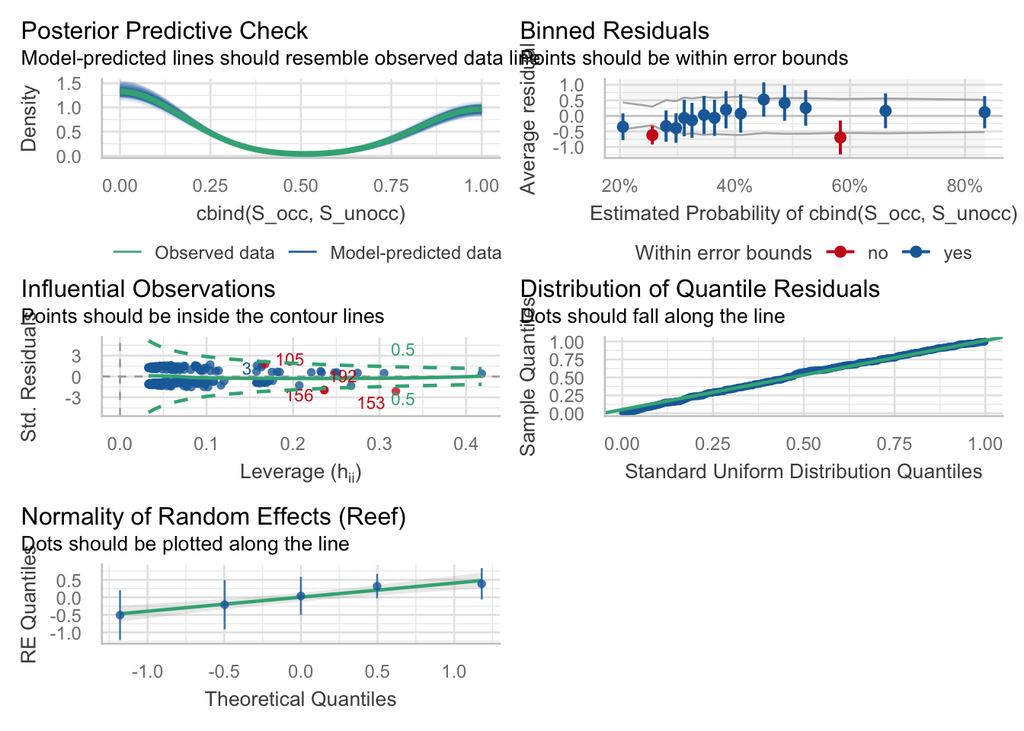

```r
check_overdispersion(glmer.occ)
```

```
## # Overdispersion test
##
##  dispersion ratio = 1.059
##           p-value =  0.44
```

```
## No overdispersion detected.
```

```r
check_collinearity(glmer.occ)
```

```
## Not enough model terms in the conditional part of the model to check for
##   multicollinearity.
```

```r
r2(glmer.occ)
```

```
## # R2 for Mixed Models
##
##   Conditional R2: 0.169
##      Marginal R2: 0.119
```

```r
sd_width <- sd(social_occ$Max_width_cm, na.rm = TRUE) #6.760123

OR_1SD <- exp(0.6869) #1.987545
OR_1cm <- exp(0.6869 / sd_width) #1.106952
```

Predictions from the standardized-width model are returned to centimeters before being plotted with the observed occupancy data. The threshold annotations follow the observed prediction grid.

```r
#Plot Model - Sponge occupancy vs sponge size + Raw data
occ.plot <- ggpredict(glmer.occ,
                      terms = c("z_Max_width_cm [all]"),
                      type = "random")
```

```
## It seems that unit-level predictions are requested (`type = "random"`),
##   but no random effects terms (grouping variables) are defined in the
##   `terms` argument. Either add a random effects term to the `terms`
##   argument, or set `type = "fixed"` to get meaningful results (in this
##   case, population-level predictions).
```

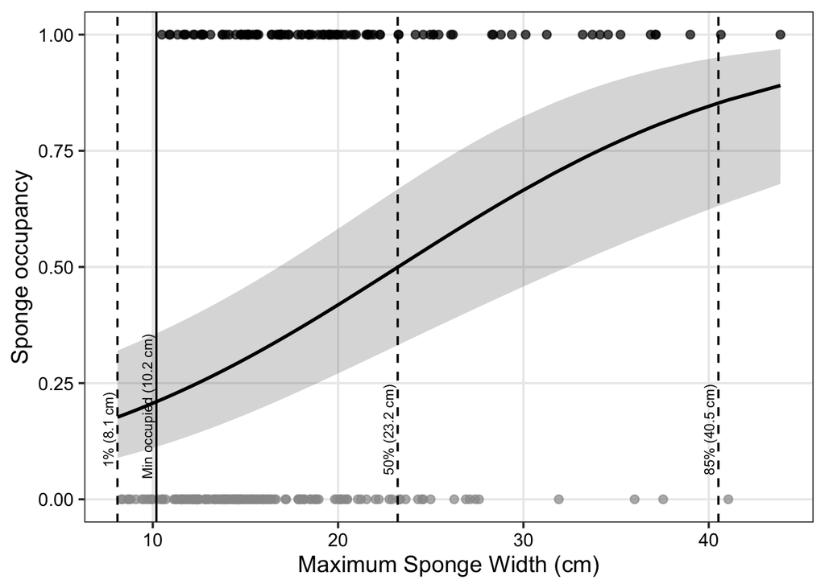

```r
occ_df <- as.data.frame(occ.plot)

width_mean <- mean(social_occ$Max_width_cm, na.rm = TRUE)
width_sd <- sd(social_occ$Max_width_cm, na.rm = TRUE)
occ_df$x <- occ_df$x * width_sd + width_mean

#Find the observed-range prediction-grid width closest to each probability.
get_size_from_grid <- function(p, df = occ_df) {
  df$x[which.min(abs(df$predicted - p))]
}

probs <- c(0.01, 0.5, 0.85)

thresholds <- data.frame(
  prob  = probs,
  size  = sapply(probs, get_size_from_grid),
  label = c("1%", "50%", "85%"))

#Extracting empirical info
min_present <- min(social_occ$Max_width_cm[social_occ$S_occ == 1], na.rm = TRUE)

empirical_df <- data.frame(
  size  = min_present,
  label = "Min occupied")

social_occ$S_occ_f <- factor(social_occ$S_occ,
                             levels = c(0, 1),
                             labels = c("Absent", "Present"))

#Plotting the model
pred.plot.occ <-
  ggplot() +
  geom_ribbon(data = occ_df,
              aes(x = x, ymin = conf.low, ymax = conf.high),
              alpha = 0.2) +
  geom_line(data = occ_df,
            aes(x = x, y = predicted),
            size = 1) +
  geom_point(data = social_occ,
    aes(x = Max_width_cm, y = S_occ, colour = S_occ_f),
    position = position_jitter(width = 0.3, height = 0),
    alpha = 0.7,
    size = 2)+
  #adding 1%, 50%, 90% thresholds
  geom_vline(data = thresholds,
             aes(xintercept = size),
             linetype = "dashed") +
  geom_text(data = thresholds,
            aes(x = size,y = 0.15, label = paste0(label, " (", round(size, 1), " cm)")),
            angle = 90, vjust = -0.4, size = 3) +
  #adding empirical min occupied sponge
  geom_vline(data = empirical_df,
             aes(xintercept = size), linetype = "solid") +
  geom_text(data = empirical_df,
            aes(x = size, y = 0.20, label = paste0("Min occupied (", round(size, 1), " cm)")),
            angle = 90, vjust = -0.4, size = 3) +
  # aesthetics
  scale_colour_manual(values = c("Absent" = "grey60", "Present" = "black")) +
  scale_y_continuous("Sponge occupancy",
                     limits = c(0, 1),
                     breaks = c(0, 0.25, 0.5, 0.75, 1)) +
  scale_x_continuous("Maximum Sponge Width (cm)") +
  theme_bw(base_size = 14) +
  theme(legend.position = "none",
    panel.grid.minor = element_blank(),
    axis.text = element_text(colour = "black"),
    plot.background = element_rect(fill = "transparent", colour = NA),
    panel.background = element_blank())
pred.plot.occ
```

```r
ggsave(file.path(output_dir, "Figure_1C.pdf"), width = 6, height = 5, units = "in")
```

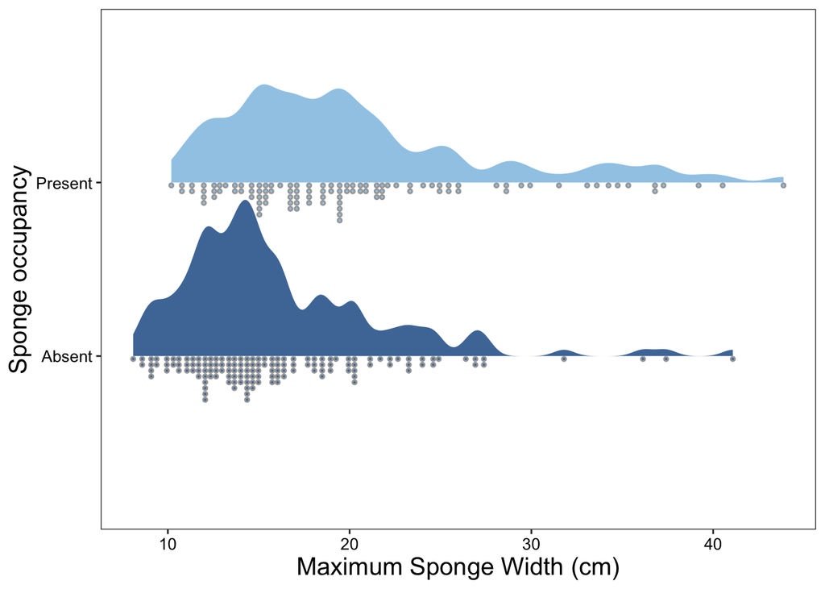

```r
#Complementary density plot
social_occ %>%
  ggplot(aes(x = factor(R_ruber), y = Max_width_cm, fill = factor(R_ruber)))+
  theme_bw() +
  theme(legend.position = "none",
        axis.text = element_text(color = "black", size = 10),
        axis.title = element_text(size = 15),
        panel.background = element_blank(),
        panel.grid.major = element_blank(),
        panel.grid.minor = element_blank())+
  stat_halfeye(
    adjust = 0.4,
    justification = 0,
    .width = 0,
    point_colour = NA
  )  +
  stat_dots(
    side = "left",
    justification = 1,
    binwidth = 0.3)+
  scale_fill_tableau("Tableau 20", name = NULL) +
  labs(
    x = "Sponge occupancy",
    y = "Maximum Sponge Width (cm)",
    fill = "Cylinders"
  ) +
  coord_flip()
```

```r
ggsave(file.path(output_dir, "Figure_1C.2.pdf"), width = 6, height = 5, units = "in")
```

Further refinement of Figure 1C was done in illustrator.

## 2. Descriptive social and habitat summaries

This section summarizes sampling by reef and sponge species, fish size, group size, sex, and social rank. These outputs document sample sizes and provide the descriptive results used in the text and supplementary figures.

Computing some basic descriptive metrics with the main social dataset before further analyses:

```r
social.all <- read.csv(file.path(data_dir, "social_data_all_complete.csv"))

head(social.all)
```

```
##      ind_id Sponge_width_cm Depth Group_size TL_mm Rank mt_lineage nc_lineage
## 1 Risor_223        16.59614  12.3          1 17.00    1         NA         NA
## 2 Risor_224        20.91269  12.6          2 21.46    1         NA         NA
## 3 Risor_225        20.91269  12.6          2 10.38    2         NA         NA
## 4 Risor_226        14.18593  12.5          1 17.43    1         NA         NA
## 5 Risor_002        20.84560   7.1          5 11.67    5         NA          1
## 6 Risor_003        20.84560   7.1          5 16.88    2         NA          1
##   Sponge_id          S_species S_colour Reef AVG.TL_mm is_male egg_count eggs
## 1    CUR_01 Ircinia strobilina   Medium  CUR    17.000       1         0    0
## 2    CUR_02      Ircinia felix   Medium  CUR    15.920       0         0    0
## 3    CUR_02      Ircinia felix   Medium  CUR    15.920      na         0    0
## 4    CUR_03 Ircinia strobilina    Light  CUR    17.430       0         0    0
## 5    GOL_01      Ircinia felix     Dark  GOL    15.364      na         0    0
## 6    GOL_01      Ircinia felix     Dark  GOL    15.364       1         0    0
##   age
## 1  NA
## 2  NA
## 3  NA
## 4  NA
## 5  NA
## 6  NA
```

```r
social.all <- social.all %>%
  mutate(
    Reef      = factor(Reef),
    Sponge_id = factor(Sponge_id),
    Rank_n    = as.integer(as.character(Rank)),
    sex = case_when(
      str_to_lower(is_male) %in% c("male","m","1","true","t")        ~ "male",
      str_to_lower(is_male) %in% c("female","f","0","false","fa")    ~ "female",
      TRUE                                                           ~ NA_character_
    ) %>% factor(levels = c("female","male"))
  )
head(social.all)
```

```
##      ind_id Sponge_width_cm Depth Group_size TL_mm Rank mt_lineage nc_lineage
## 1 Risor_223        16.59614  12.3          1 17.00    1         NA         NA
## 2 Risor_224        20.91269  12.6          2 21.46    1         NA         NA
## 3 Risor_225        20.91269  12.6          2 10.38    2         NA         NA
## 4 Risor_226        14.18593  12.5          1 17.43    1         NA         NA
## 5 Risor_002        20.84560   7.1          5 11.67    5         NA          1
## 6 Risor_003        20.84560   7.1          5 16.88    2         NA          1
##   Sponge_id          S_species S_colour Reef AVG.TL_mm is_male egg_count eggs
## 1    CUR_01 Ircinia strobilina   Medium  CUR    17.000       1         0    0
## 2    CUR_02      Ircinia felix   Medium  CUR    15.920       0         0    0
## 3    CUR_02      Ircinia felix   Medium  CUR    15.920      na         0    0
## 4    CUR_03 Ircinia strobilina    Light  CUR    17.430       0         0    0
## 5    GOL_01      Ircinia felix     Dark  GOL    15.364      na         0    0
## 6    GOL_01      Ircinia felix     Dark  GOL    15.364       1         0    0
##   age Rank_n    sex
## 1  NA      1   male
## 2  NA      1 female
## 3  NA      2   <NA>
## 4  NA      1 female
## 5  NA      5   <NA>
## 6  NA      2   male
```

```r
social.all <- social.all %>%
  mutate(
    z_Sponge_width_cm = scale(Sponge_width_cm),
    z_TL_mm           = scale(TL_mm)
  )
```

#### Sponge metrics

```r
sponges_per_site <- social.all %>%
  distinct(Reef, Sponge_id) %>%      #each sponge counted once per reef
  count(Reef, name = "n_sponges")

sponges_per_site
```

```
##   Reef n_sponges
## 1  CUR         3
## 2  GOL        56
## 3  GRU        32
## 4  LON        13
```

```r
sponges_summary <- sponges_per_site %>%
  summarise(
    mean_sponges = mean(n_sponges),
    sd_sponges   = sd(n_sponges),
    min_sponges  = min(n_sponges),
    max_sponges  = max(n_sponges),
    n_sites = n()
  )

sponges_summary
```

```
##   mean_sponges sd_sponges min_sponges max_sponges n_sites
## 1           26   23.33809           3          56       4
```

```r
sponges_per_site_species <- social.all %>%
  distinct(Reef, S_species, Sponge_id) %>%  # each sponge once per reef × species
  count(Reef, S_species, name = "n_sponges")

sponges_per_site_species
```

```
##    Reef          S_species n_sponges
## 1   CUR      Ircinia felix         1
## 2   CUR Ircinia strobilina         2
## 3   GOL    Ircinia campana        21
## 4   GOL      Ircinia felix        26
## 5   GOL  Ircinia ruetzleri         3
## 6   GOL Ircinia strobilina         6
## 7   GRU    Ircinia campana         9
## 8   GRU      Ircinia felix        15
## 9   GRU  Ircinia ruetzleri         3
## 10  GRU Ircinia strobilina         6
## 11  LON    Ircinia campana         2
## 12  LON      Ircinia felix        10
## 13  LON Ircinia strobilina         1
```

```r
species_summary <- sponges_per_site_species %>%
  group_by(S_species) %>%
  summarise(
    n_occupied = sum(n_sponges),   #total occupied sponges of that species
    .groups = "drop"
  ) %>%
  mutate(
    percent_occupied = 100 * n_occupied / sum(n_occupied)
  )
species_summary <- species_summary %>%
  arrange(desc(percent_occupied))
```

#### Fish total length summaries

```r
#Overall
tl_overall <- social.all %>%
  summarise(
    n          = sum(!is.na(TL_mm)),
    mean_TL    = mean(TL_mm, na.rm = TRUE),
    sd_TL      = sd(TL_mm, na.rm = TRUE),
    min_TL     = min(TL_mm, na.rm = TRUE),
    max_TL     = max(TL_mm, na.rm = TRUE)
  )

tl_overall
```

```
##     n  mean_TL    sd_TL min_TL max_TL
## 1 223 14.38328 3.140496   7.34  23.22
```

```r
#By sex
tl_by_sex <- social.all %>%
  filter(!is.na(sex)) %>%
  group_by(sex) %>%
  summarise(
    n          = n(),
    mean_TL    = mean(TL_mm, na.rm = TRUE),
    sd_TL      = sd(TL_mm, na.rm = TRUE),
    min_TL     = min(TL_mm, na.rm = TRUE),
    max_TL     = max(TL_mm, na.rm = TRUE),
    .groups    = "drop"
  )

tl_by_sex
```

```
## # A tibble: 2 × 6
##   sex        n mean_TL sd_TL min_TL max_TL
##   <fct>  <int>   <dbl> <dbl>  <dbl>  <dbl>
## 1 female   162    14.1  2.74   8.86   21.5
## 2 male      45    17.0  2.54  12.9    23.2
```

#### Group size distribution

```r
group_df <- social.all %>%
  distinct(Sponge_id, Reef, Group_size)

group_size_summary <- group_df %>%
  summarise(
    n_groups      = n(),
    median_gsize    = median(Group_size, na.rm = TRUE),
    min_gsize     = min(Group_size, na.rm = TRUE),
    max_gsize     = max(Group_size, na.rm = TRUE)
  )

group_size_summary
```

```
##   n_groups median_gsize min_gsize max_gsize
## 1      104            2         1        14
```

```r
group_size_freq <- group_df %>%
  count(Group_size, name = "n_groups") %>%
  arrange(Group_size)

group_size_freq
```

```
##   Group_size n_groups
## 1          1       49
## 2          2       30
## 3          3       11
## 4          4        7
## 5          5        3
## 6          7        2
## 7         10        1
## 8         14        1
```

#### Rank distribution

```r
rank_counts <- social.all %>%
  count(Rank_n, name = "n_ind") %>%
  arrange(Rank_n)

rank_counts
```

```
##    Rank_n n_ind
## 1       1   104
## 2       2    55
## 3       3    25
## 4       4    14
## 5       5     7
## 6       6     4
## 7       7     4
## 8       8     2
## 9       9     2
## 10     10     2
## 11     11     1
## 12     12     1
## 13     13     1
## 14     14     1
```

#### Sex ratio overall and by rank

```r
#Overall sex ratio
sex_overall <- social.all%>%
  filter(!is.na(sex)) %>%
  count(sex, name = "n") %>%
  mutate(
    prop = n / sum(n)
  )

sex_overall
```

```
##      sex   n      prop
## 1 female 162 0.7826087
## 2   male  45 0.2173913
```

```r
# Sex by rank (for rank × sex figure and text)
sex_by_rank <- social.all %>%
  filter(!is.na(sex), !is.na(Rank_n)) %>%
  count(Rank_n, sex, name = "n") %>%
  group_by(Rank_n) %>%
  mutate(
    total_rank = sum(n),
    prop       = n / total_rank
  ) %>%
  ungroup() %>%
  arrange(Rank_n, sex)

sex_by_rank
```

```
## # A tibble: 22 × 5
##    Rank_n sex        n total_rank   prop
##     <int> <fct>  <int>      <int>  <dbl>
##  1      1 female    74        100 0.74
##  2      1 male      26        100 0.26
##  3      2 female    40         50 0.8
##  4      2 male      10         50 0.2
##  5      3 female    21         23 0.913
##  6      3 male       2         23 0.0870
##  7      4 female    10         12 0.833
##  8      4 male       2         12 0.167
##  9      5 female     5          6 0.833
## 10      5 male       1          6 0.167
## # ℹ 12 more rows
```

#### Occupied sponges by reef and host species

Occupied sponges are counted by reef and host species. The expected output is Supplementary Figure S5.

```r
sponge <- social.all %>%           # or your full social dataframe
  group_by(Sponge_id, S_species, Reef) %>%
  summarise(
    Group_size      = n(),
    Sponge_width_cm = first(Sponge_width_cm),
    .groups = "drop"
  ) #106 sponges
```

```r
counts <- sponge %>%
  count(Reef, S_species, name = "freq")

counts <- counts %>%
  group_by(Reef) %>%
  mutate(total_site = sum(freq)) %>%
  ungroup() %>%
  mutate(Reef = reorder(Reef, total_site))

counts
```

```
## # A tibble: 13 × 4
##    Reef  S_species           freq total_site
##    <fct> <chr>              <int>      <int>
##  1 CUR   Ircinia felix          1          3
##  2 CUR   Ircinia strobilina     2          3
##  3 GOL   Ircinia campana       21         56
##  4 GOL   Ircinia felix         26         56
##  5 GOL   Ircinia ruetzleri      3         56
##  6 GOL   Ircinia strobilina     6         56
##  7 GRU   Ircinia campana        9         33
##  8 GRU   Ircinia felix         15         33
##  9 GRU   Ircinia ruetzleri      3         33
## 10 GRU   Ircinia strobilina     6         33
## 11 LON   Ircinia campana        2         13
## 12 LON   Ircinia felix         10         13
## 13 LON   Ircinia strobilina     1         13
```

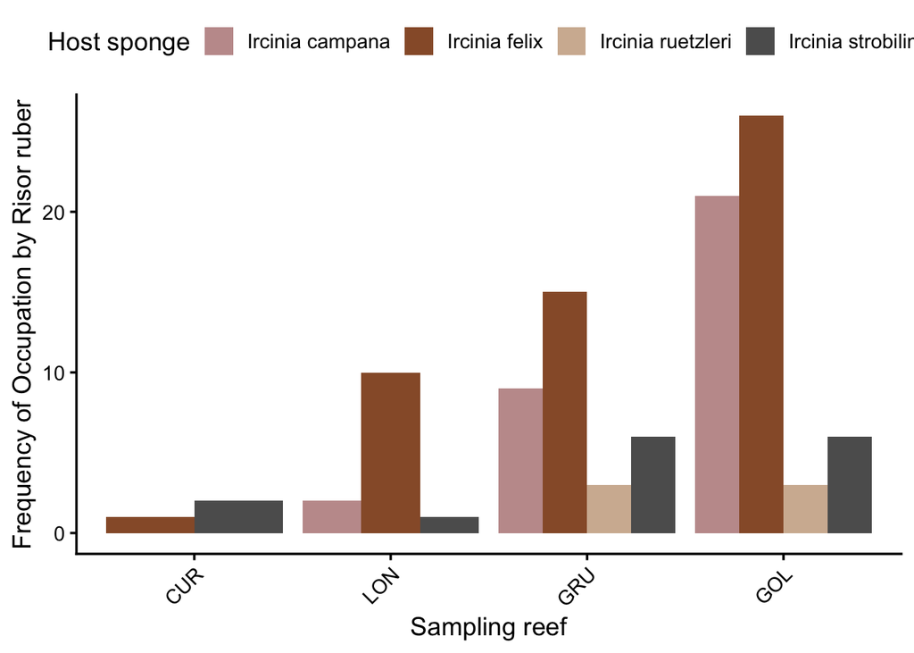

```r
ggplot(counts, aes(x = Reef, y = freq, fill = S_species)) +
  geom_col(position = "dodge", alpha = 0.9) +
  scale_fill_manual(values = c(
    "Ircinia campana"    = "rosybrown",
    "Ircinia felix"      = "saddlebrown",
    "Ircinia strobilina" = "grey28",
    "Ircinia ruetzleri"  = "peachpuff3"
  )) +
  labs(
    x = "Sampling reef",
    y = "Frequency of Occupation by Risor ruber",
    fill = "Host sponge"
  ) +
  theme_classic(base_size = 14) +
  theme(legend.position = "top") +
  theme(axis.text.x = element_text(angle = 45, hjust = 1))
```

```r
ggsave(file.path(output_dir, "Figure_S5.pdf"), width = 7, height = 5, units = "in")
```

## 3. Social organization

This section quantifies adjacent-rank size ratios and tests whether group-size structure changes with group size and habitat characteristics. It produces the group-structure summaries and figures used to describe size-based social organization.

### Adjacent-rank size ratios

For each social group, the total length of a subordinate is divided by the length of the individual immediately above it in rank. Ratios closer to one indicate more similar body sizes, whereas smaller ratios indicate a steeper size hierarchy. The expected output is Supplementary Figure S8.

```r
#orderining individuals within each group
df_ratios<- social.all %>%
  mutate(Rank_n = as.numeric(as.character(Rank)))%>%
  arrange(Sponge_id, Rank_n)

# add "next" fish in rank and compute adjacent size ratio
df_ratios <- df_ratios %>%
  group_by(Sponge_id) %>%
  arrange(Rank_n, .by_group = TRUE) %>%
  mutate(
    next_TL  = lead(TL_mm),
    next_rank = lead(Rank_n),
    ratio    = next_TL / TL_mm,
    Ratio_ID = ifelse(
      is.na(next_TL),
      NA_character_,
      sprintf("R%02d/R%02d", next_rank, Rank_n)
    )
  ) %>%
  ungroup()

#summarize to group-level means (Group.ratio)
group_ratio_df <- df_ratios %>%
  group_by(Sponge_id, Reef) %>%
  summarise(
    Group.size  = n(),
    Group.ratio = if (sum(!is.na(ratio)) > 0) {
      mean(ratio, na.rm = TRUE)
    } else {
      NA_real_
    },
    .groups = "drop"
  )


#transforming to wide format
ratio_wide <- df_ratios %>%
  filter(!is.na(ratio)) %>%
  dplyr::select(Sponge_id, Ratio_ID, ratio) %>%
  pivot_wider(
    names_from  = Ratio_ID,
    values_from = ratio
  )

summary_wide <- group_ratio_df %>%
  left_join(ratio_wide, by = "Sponge_id")


#group ratio - long format
ratio_long_df <- df_ratios %>%
  filter(!is.na(ratio)) %>%
  transmute(
    Sponge_id,
    Reef,
    Group.size = ave(Rank_n, Sponge_id, FUN = length),
    Ratio_ID,
    Ratio_long = ratio
  )

ratio_long_df <- df_ratios %>%
  mutate(Rank_n = as.numeric(as.character(Rank))) %>%
  arrange(Sponge_id, Rank_n) %>%
  group_by(Sponge_id) %>%
  mutate(
    next_TL   = dplyr::lead(TL_mm),
    next_rank = dplyr::lead(Rank_n),
    Ratio_long = next_TL / TL_mm,
    Ratio_ID   = ifelse(
      is.na(next_TL),
      NA_character_,
      sprintf("R%02d/R%02d", next_rank, Rank_n)
    )
  ) %>%
  ungroup() %>%
  filter(!is.na(Ratio_long), !is.na(Ratio_ID))
```

```r
#obtain ratio summary of each individual
ratio_summary <- ratio_long_df %>%
  group_by(Ratio_ID) %>%
  summarise(
    mean_ratio = mean(Ratio_long, na.rm = TRUE),
    sd_ratio   = sd(Ratio_long, na.rm = TRUE),
    se_ratio   = sd_ratio / sqrt(n()),
    n          = n(),
    .groups    = "drop"
  ) %>%
  mutate(Ratio_ID = factor(Ratio_ID, levels = sort(unique(Ratio_ID))))

ratio_summary
```

```
## # A tibble: 13 × 5
##    Ratio_ID mean_ratio sd_ratio se_ratio     n
##    <fct>         <dbl>    <dbl>    <dbl> <int>
##  1 R02/R01       0.838   0.119    0.0160    55
##  2 R03/R02       0.878   0.0953   0.0191    25
##  3 R04/R03       0.875   0.131    0.0349    14
##  4 R05/R04       0.931   0.0417   0.0157     7
##  5 R06/R05       0.911   0.120    0.0601     4
##  6 R07/R06       0.953   0.0518   0.0259     4
##  7 R08/R07       0.949   0.0612   0.0433     2
##  8 R09/R08       0.970   0.0302   0.0214     2
##  9 R10/R09       0.964   0.0330   0.0234     2
## 10 R11/R10       0.972  NA       NA          1
## 11 R12/R11       0.999  NA       NA          1
## 12 R13/R12       0.736  NA       NA          1
## 13 R14/R13       0.905  NA       NA          1
```

The following plot retains rank pairs with sufficient replication to calculate a standard error.

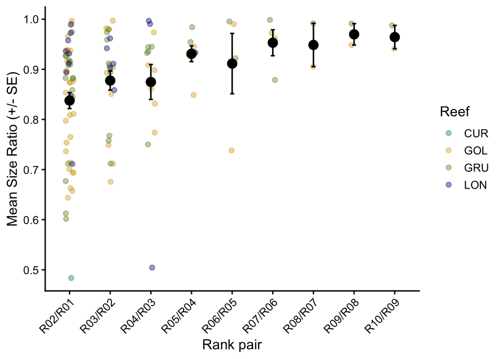

```r
# reorder rank pairs in natural order
summary_ratios <- ratio_summary %>%
  mutate(Ratio_ID = factor(Ratio_ID, levels = Ratio_ID))%>%
  filter(!is.na(se_ratio))

ratio_long_clean <- ratio_long_df %>%
  filter(Ratio_ID %in% summary_ratios$Ratio_ID)

ggplot() +
  # Raw ratios (transparent points)
  geom_jitter(data = ratio_long_clean,
              aes(x = Ratio_ID, y = ratio, color = Reef),
              width = 0.1, height = 0,
              alpha = 0.4, size = 2) +

  # Means + SE
  geom_point(data = summary_ratios,
             aes(x = Ratio_ID, y = mean_ratio),
             size = 4, color = "black") +

  geom_errorbar(data = summary_ratios,
                aes(x = Ratio_ID,
                    ymin = mean_ratio - se_ratio,
                    ymax = mean_ratio + se_ratio),
                width = 0.1, linewidth = 0.7) +
  scale_color_manual(values = c("CUR"="#008B8B", "GOL" = "#DAA520", "GRU" = "#6B8E23", "LON" = "#000080"))+
  labs(x = "Rank pair",
       y = "Mean Size Ratio (+/- SE)") +

  theme_classic(base_size = 14) +
  theme(axis.text.x = element_text(angle = 45, hjust = 1))
```

```r
ggsave(file.path(output_dir, "Figure_S8.pdf"), width = 7, height = 5, units = "in")
```

### Group size and hierarchy steepness

The beta mixed model tests whether adjacent-rank size ratios change with group size while accounting for reef. The model evaluates whether larger groups have steeper or flatter size hierarchies.

Determine how steep or shallow the size hierarchy is Mean ratio close to 1 - means individuals are very similar in size (weak hierarchy) Mean ratio lower than that - individuals differ strongly - steep hierarchy

This number is a shape descriptor of the dominance/size structure of a group

Model - when groups get larger, are size differences between rank positions amplified or compressed? Does adding more individuals reinforce the hierarchy, or dilute it?

H1: Larger groups -> steeper hierarchy (lower ratios) This would suggest strong competition within confined space; bigger individual monopolize resources; subordinate individuals get smaller relative to dominants

H2: Larger groups -> flatter hierarchy (higher ratios) This would suggest that groups tolerate similarly sized individuals; size-based dominance is relaxed; the resource (sponge) provided enough microhabitats. This is probably the most plausible scenario for microhabitat-limited species

```r
#Model - does the size structure of groups depend on how large the group is?
#Do bigger groups have more competitive, more size-structured hierarchies?

m_gratio = glmmTMB(Group.ratio ~ Group.size + (1|Reef), family = beta_family(link = "logit"), data=summary_wide)

summary(m_gratio)
```

```
##  Family: beta  ( logit )
## Formula:          Group.ratio ~ Group.size + (1 | Reef)
## Data: summary_wide
##
##       AIC       BIC    logLik -2*log(L)  df.resid
##     -99.0     -90.9      53.5    -107.0        51
##
## Random effects:
##
## Conditional model:
##  Groups Name        Variance  Std.Dev.
##  Reef   (Intercept) 3.606e-10 1.899e-05
## Number of obs: 55, groups:  Reef, 4
##
## Dispersion parameter for beta family (): 11.6
##
## Conditional model:
##             Estimate Std. Error z value Pr(>|z|)
## (Intercept)  1.31868    0.18832   7.002 2.52e-12 ***
## Group.size   0.09964    0.05418   1.839   0.0659 .
## ---
## Signif. codes:  0 '***' 0.001 '**' 0.01 '*' 0.05 '.' 0.1 ' ' 1
```

```r
#Model checks
check_model(m_gratio)
```

```
## `check_outliers()` does not yet support models of class `glmmTMB`.
```

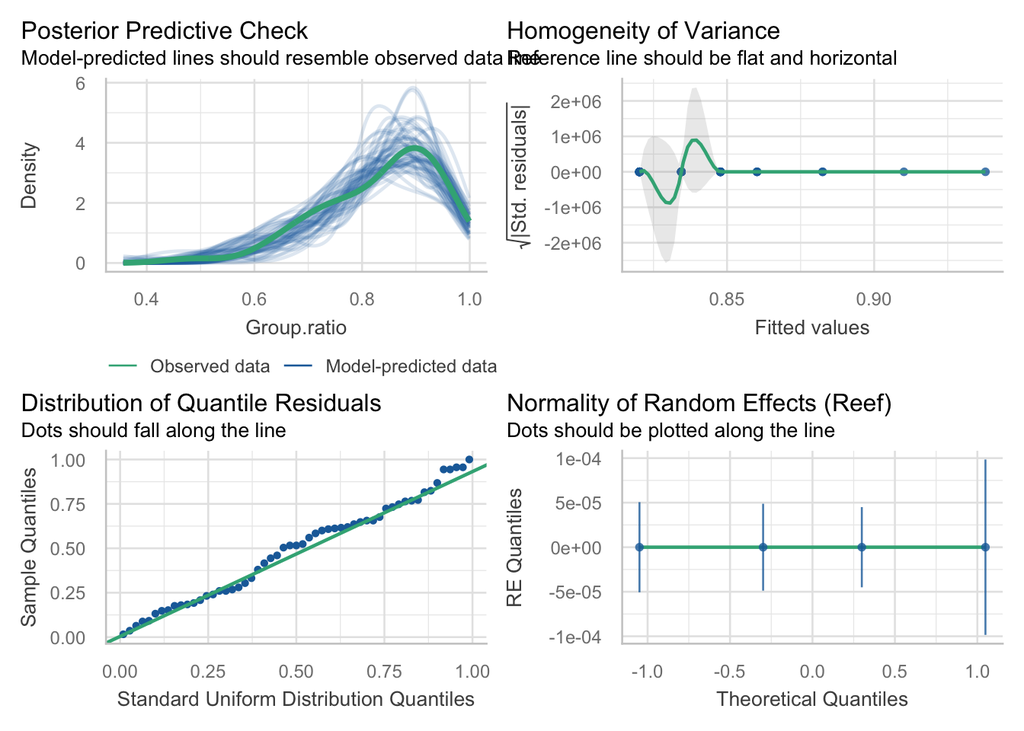

```r
check_residuals(m_gratio) #uniformly distributed
```

```
## OK: Simulated residuals appear as uniformly distributed (p = 0.848).
```

```r
model_performance(m_gratio)
```

```
## Random effect variances not available. Returned R2 does not account for random effects.
```

```
## # Indices of model performance
##
## AIC   |  AICc |   BIC | R2 (cond.) | R2 (marg.) |  RMSE |  Sigma
## ----------------------------------------------------------------
## -99.0 | -98.2 | -90.9 |            |      0.747 | 0.101 | 11.638
```

#### Visualizing social structure across group sizes

```r
social_data<- social.all

#number of R. ruber located within one sponge ranged from 1-14 individuals
#N of each group size: 1=50, 2=30, 3=11, 4=7, 5=3, 7=2, 10=1, 14=1).
head(social_data)
```

```
##      ind_id Sponge_width_cm Depth Group_size TL_mm Rank mt_lineage nc_lineage
## 1 Risor_223        16.59614  12.3          1 17.00    1         NA         NA
## 2 Risor_224        20.91269  12.6          2 21.46    1         NA         NA
## 3 Risor_225        20.91269  12.6          2 10.38    2         NA         NA
## 4 Risor_226        14.18593  12.5          1 17.43    1         NA         NA
## 5 Risor_002        20.84560   7.1          5 11.67    5         NA          1
## 6 Risor_003        20.84560   7.1          5 16.88    2         NA          1
##   Sponge_id          S_species S_colour Reef AVG.TL_mm is_male egg_count eggs
## 1    CUR_01 Ircinia strobilina   Medium  CUR    17.000       1         0    0
## 2    CUR_02      Ircinia felix   Medium  CUR    15.920       0         0    0
## 3    CUR_02      Ircinia felix   Medium  CUR    15.920      na         0    0
## 4    CUR_03 Ircinia strobilina    Light  CUR    17.430       0         0    0
## 5    GOL_01      Ircinia felix     Dark  GOL    15.364      na         0    0
## 6    GOL_01      Ircinia felix     Dark  GOL    15.364       1         0    0
##   age Rank_n    sex z_Sponge_width_cm    z_TL_mm
## 1  NA      1   male        -0.7380139  0.8332178
## 2  NA      1 female        -0.2195362  2.2533754
## 3  NA      2   <NA>        -0.2195362 -1.2747292
## 4  NA      1 female        -1.0275121  0.9701388
## 5  NA      5   <NA>        -0.2275949 -0.8639661
## 6  NA      2   male        -0.2275949  0.7950073
```

```r
str(social_data)
```

```
## 'data.frame':    223 obs. of  21 variables:
##  $ ind_id           : chr  "Risor_223" "Risor_224" "Risor_225" "Risor_226" ...
##  $ Sponge_width_cm  : num  16.6 20.9 20.9 14.2 20.8 ...
##  $ Depth            : num  12.3 12.6 12.6 12.5 7.1 7.1 7.1 7.1 7.1 7.3 ...
##  $ Group_size       : int  1 2 2 1 5 5 5 5 5 3 ...
##  $ TL_mm            : num  17 21.5 10.4 17.4 11.7 ...
##  $ Rank             : int  1 1 2 1 5 2 1 3 4 1 ...
##  $ mt_lineage       : int  NA NA NA NA NA NA NA NA NA 2 ...
##  $ nc_lineage       : int  NA NA NA NA 1 1 NA NA NA NA ...
##  $ Sponge_id        : Factor w/ 104 levels "CUR_01","CUR_02",..: 1 2 2 3 4 4 4 4 4 5 ...
##  $ S_species        : chr  "Ircinia strobilina" "Ircinia felix" "Ircinia felix" "Ircinia strobilina" ...
##  $ S_colour         : chr  "Medium" "Medium" "Medium" "Light" ...
##  $ Reef             : Factor w/ 4 levels "CUR","GOL","GRU",..: 1 1 1 1 2 2 2 2 2 2 ...
##  $ AVG.TL_mm        : num  17 15.9 15.9 17.4 15.4 ...
##  $ is_male          : chr  "1" "0" "na" "0" ...
##  $ egg_count        : int  0 0 0 0 0 0 0 70 0 0 ...
##  $ eggs             : int  0 0 0 0 0 0 0 1 0 0 ...
##  $ age              : int  NA NA NA NA NA NA NA NA NA NA ...
##  $ Rank_n           : int  1 1 2 1 5 2 1 3 4 1 ...
##  $ sex              : Factor w/ 2 levels "female","male": 2 1 NA 1 NA 2 1 1 1 2 ...
##  $ z_Sponge_width_cm: num [1:223, 1] -0.738 -0.22 -0.22 -1.028 -0.228 ...
##   ..- attr(*, "scaled:center")= num 22.7
##   ..- attr(*, "scaled:scale")= num 8.33
##  $ z_TL_mm          : num [1:223, 1] 0.833 2.253 -1.275 0.97 -0.864 ...
##   ..- attr(*, "scaled:center")= num 14.4
##   ..- attr(*, "scaled:scale")= num 3.14
```

```r
#change string
social_data$Group_size <- as.integer(social_data$Group_size)
social_data$ind_id <- as.factor(social_data$ind_id)
social_data$Rank <- as.factor(social_data$Rank)
social_data$Sponge_id <- as.factor(social_data$Sponge_id)
social_data$S_species <- as.factor(social_data$S_species)
social_data$Sponge_id <- as.factor(social_data$Sponge_id)
social_data$S_colour <- as.factor(social_data$S_colour)
social_data$Reef <- as.factor(social_data$Reef)

#summarize data
sumdat <- social_data %>%
  group_by(Rank, Group_size) %>%
  summarise(
    meanTL = mean(TL_mm, na.rm = TRUE),
    seTL   = sd(TL_mm, na.rm = TRUE) / sqrt(n()),
    .groups = "drop"
  ) %>%
  mutate(Rank = as.integer(as.character(Rank)))

keep <- c(1,2,3,4,5,7,10,14)

sumdat <- sumdat %>%
  filter(Group_size %in% keep)
```

```
## `geom_line()`: Each group consists of only one observation.
## ℹ Do you need to adjust the group aesthetic?
```

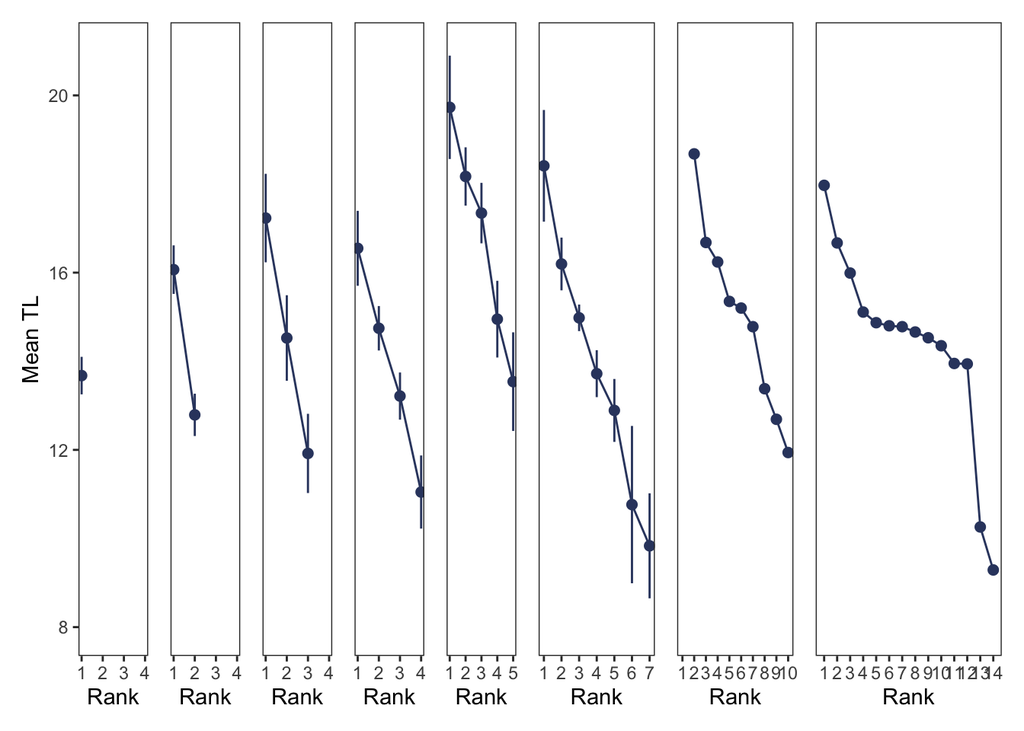

```r
#Organize sclaes
ymin <- min(sumdat$meanTL - sumdat$seTL, na.rm = TRUE)
ymax <- max(sumdat$meanTL + sumdat$seTL, na.rm = TRUE)

#base theme
base_theme <- theme_bw() +
  theme(
    legend.position = "none",
    panel.grid = element_blank(),
    axis.title.y = element_blank(),
    axis.text.y  = element_blank(),
    axis.ticks.y = element_blank()
  )

#individual panels
p1 <- ggplot(filter(sumdat, Group_size==1),
             aes(Rank, meanTL)) +
  geom_line(color="#34446e") +
  geom_point(color="#34446e", size=2) +
  geom_linerange(aes(ymin=meanTL-seTL, ymax=meanTL+seTL),
                 color="#34446e") +
  scale_x_continuous(limits=c(1,4), breaks=1:4) +
  scale_y_continuous(limits=c(floor(ymin), ceiling(ymax))) +
  labs(y="Mean TL") +
  theme_bw() +
  theme(panel.grid = element_blank())

p2 <- ggplot(filter(sumdat, Group_size==2),
             aes(Rank, meanTL)) +
  geom_line(color="#34446e") +
  geom_point(color="#34446e", size=2) +
  geom_linerange(aes(ymin=meanTL-seTL, ymax=meanTL+seTL),
                 color="#34446e") +
  scale_x_continuous(limits=c(1,4), breaks=1:4) +
  scale_y_continuous(limits=c(floor(ymin), ceiling(ymax))) +
  base_theme

p3 <- ggplot(filter(sumdat, Group_size==3),
             aes(Rank, meanTL)) +
  geom_line(color="#34446e") +
  geom_point(color="#34446e", size=2) +
  geom_linerange(aes(ymin=meanTL-seTL, ymax=meanTL+seTL),
                 color="#34446e") +
  scale_x_continuous(limits=c(1,4), breaks=1:4) +
  scale_y_continuous(limits=c(floor(ymin), ceiling(ymax))) +
  base_theme

p4 <- ggplot(filter(sumdat, Group_size==4),
             aes(Rank, meanTL)) +
  geom_line(color="#34446e") +
  geom_point(color="#34446e", size=2) +
  geom_linerange(aes(ymin=meanTL-seTL, ymax=meanTL+seTL),
                 color="#34446e") +
  scale_x_continuous(limits=c(1,4), breaks=1:4) +
  scale_y_continuous(limits=c(floor(ymin), ceiling(ymax))) +
  base_theme

p5 <- ggplot(filter(sumdat, Group_size==5),
             aes(Rank, meanTL)) +
  geom_line(color="#34446e") +
  geom_point(color="#34446e", size=2) +
  geom_linerange(aes(ymin=meanTL-seTL, ymax=meanTL+seTL),
                 color="#34446e") +
  scale_x_continuous(limits=c(1,5), breaks=1:5) +
  scale_y_continuous(limits=c(floor(ymin), ceiling(ymax))) +
  base_theme

p7 <- ggplot(filter(sumdat, Group_size==7),
             aes(Rank, meanTL)) +
  geom_line(color="#34446e") +
  geom_point(color="#34446e", size=2) +
  geom_linerange(aes(ymin=meanTL-seTL, ymax=meanTL+seTL),
                 color="#34446e") +
  scale_x_continuous(limits=c(1,7), breaks=1:7) +
  scale_y_continuous(limits=c(floor(ymin), ceiling(ymax))) +
  base_theme

p10 <- ggplot(filter(sumdat, Group_size==10),
              aes(Rank, meanTL)) +
  geom_line(color="#34446e") +
  geom_point(color="#34446e", size=2) +
  geom_linerange(aes(ymin=meanTL-seTL, ymax=meanTL+seTL),
                 color="#34446e") +
  scale_x_continuous(limits=c(1,10), breaks=1:10) +
  scale_y_continuous(limits=c(floor(ymin), ceiling(ymax))) +
  base_theme

p14 <- ggplot(filter(sumdat, Group_size==14),
              aes(Rank, meanTL)) +
  geom_line(color="#34446e") +
  geom_point(color="#34446e", size=2) +
  geom_linerange(aes(ymin=meanTL-seTL, ymax=meanTL+seTL),
                 color="#34446e") +
  scale_x_continuous(limits=c(1,14), breaks=1:14) +
  scale_y_continuous(limits=c(floor(ymin), ceiling(ymax))) +
  base_theme

#combine with patchwork
pall<- (p1 | p2 | p3 | p4 | p5 | p7 | p10 | p14) +
  plot_layout(widths = c(3, 3, 3, 3, 3, 5, 5, 8))

pall
```

```r
ggsave(file.path(output_dir, "Figure_3A.pdf"), plot = pall, width = 12, height = 4, dpi = 600)
```

```
## `geom_line()`: Each group consists of only one observation.
## ℹ Do you need to adjust the group aesthetic?
```

Further refinement of Figure 3A was done in illustrator.

### Piecewise structural equation model

```r
#Organizing df for SEM model
sem_df <- social.all %>%
  mutate(Rank_n  = as.integer(Rank),
         rank_lab = paste0("R", Rank_n, "_TL")) %>%
  dplyr::filter(Rank_n %in% 1:3) %>%
  dplyr::select(Sponge_id,Reef, S_width_cm = Sponge_width_cm, Group_size, rank_lab, TL_mm) %>%
  pivot_wider(names_from  = rank_lab, values_from = TL_mm) %>%
  filter(!is.na(R1_TL), !is.na(R2_TL), !is.na(R3_TL))
```

```r
#tidy data and check distribution of target variable
sem_df <- sem_df %>%
  mutate(log_width = log(S_width_cm),
         Reef = factor(Reef))

#hist(social.data.clean$Group_size) #poisson distribution
```

```r
#SEM - Piecewise structural equation modeling
#unites structural equations in a single model

sem_mod <- psem(
  lmer(R1_TL ~ log_width + (1|Reef), data = sem_df),
  lmer(R2_TL ~ R1_TL     + (1|Reef), data = sem_df),
  lmer(R3_TL ~ R2_TL     + (1|Reef), data = sem_df),
  glmer(Group_size ~ log_width + R1_TL + (1|Reef),
        family = poisson, data = sem_df)
)
sem_output <- summary(sem_mod)
```

[output not shown]

[output not shown]

[output not shown]

[output not shown]

[output not shown]

[output not shown]

```r
plot(sem_mod) #the actual paper figure (Figure 3B) was produced on illustrator.
```

[interactive chart not shown]

### Host species and group size

The following negative-binomial models test whether host species adds explanatory value beyond sponge width for variation in group size. Only host species represented by at least 10 sponges are retained. Model comparison and the species-specific prediction curves provide the results shown in Supplementary Figure S9.

```r
#Restricting to only abundant species (>10) before modeling

sponge <- social.all %>%
  group_by(Sponge_id, S_species, Reef) %>%
  summarise(
    Group_size      = n(),
    Sponge_width_cm = first(Sponge_width_cm),
    .groups = "drop"
  ) #106 sponges


species_counts <- table(sponge$S_species)

common_species <- names(species_counts[species_counts >= 10])

common_species
```

```
## [1] "Ircinia campana"    "Ircinia felix"      "Ircinia strobilina"
```

```r
groups_main <- sponge %>%
  filter(S_species %in% common_species)

m_mix_width_main <- glmmTMB(
  Group_size ~ scale(Sponge_width_cm) + (1 | Reef),
  family = nbinom2,
  data   = groups_main
)

m_mix_main <- glmmTMB(
  Group_size ~ scale(Sponge_width_cm) + S_species + (1 | Reef),
  family = nbinom2,
  data   = groups_main
)

AIC(m_mix_width_main, m_mix_main)
```

```
##                  df      AIC
## m_mix_width_main  4 342.5362
## m_mix_main        6 331.6937
```

```r
summary(m_mix_main)
```

```
##  Family: nbinom2  ( log )
## Formula:          Group_size ~ scale(Sponge_width_cm) + S_species + (1 | Reef)
## Data: groups_main
##
##       AIC       BIC    logLik -2*log(L)  df.resid
##     331.7     347.3    -159.8     319.7        93
##
## Random effects:
##
## Conditional model:
##  Groups Name        Variance  Std.Dev.
##  Reef   (Intercept) 1.757e-10 1.325e-05
## Number of obs: 99, groups:  Reef, 4
##
## Dispersion parameter for nbinom2 family (): 60.1
##
## Conditional model:
##                             Estimate Std. Error z value Pr(>|z|)
## (Intercept)                  0.39241    0.15289   2.567   0.0103 *
## scale(Sponge_width_cm)       0.34028    0.07556   4.503 6.69e-06 ***
## S_speciesIrcinia felix       0.32331    0.19835   1.630   0.1031
## S_speciesIrcinia strobilina  0.80535    0.19592   4.111 3.95e-05 ***
## ---
## Signif. codes:  0 '***' 0.001 '**' 0.01 '*' 0.05 '.' 0.1 ' ' 1
```

Group size increased strongly with sponge width, and host identity accounted for additional variation beyond this effect (negative binomial GLMM, three common host species). For sponges of the same width, groups in I. strobilina were substantially larger than those in I. campana (≈ exp(0.81) ≈ 2.2× larger), whereas groups in I. felix did not differ significantly from I. campana.

```r
pred_group <- ggpredict(m_mix_main, terms = c("Sponge_width_cm [all]", "S_species"))
```

```
## You are calculating adjusted predictions on the population-level (i.e.
##   `type = "fixed"`) for a *generalized* linear mixed model.
##   This may produce biased estimates due to Jensen's inequality. Consider
##   setting `bias_correction = TRUE` to correct for this bias.
##   See also the documentation of the `bias_correction` argument.
```

```
## Some of the focal terms are of type `character`. This may lead to
##   unexpected results. It is recommended to convert these variables to
##   factors before fitting the model.
##   The following variables are of type character: `S_species`
```

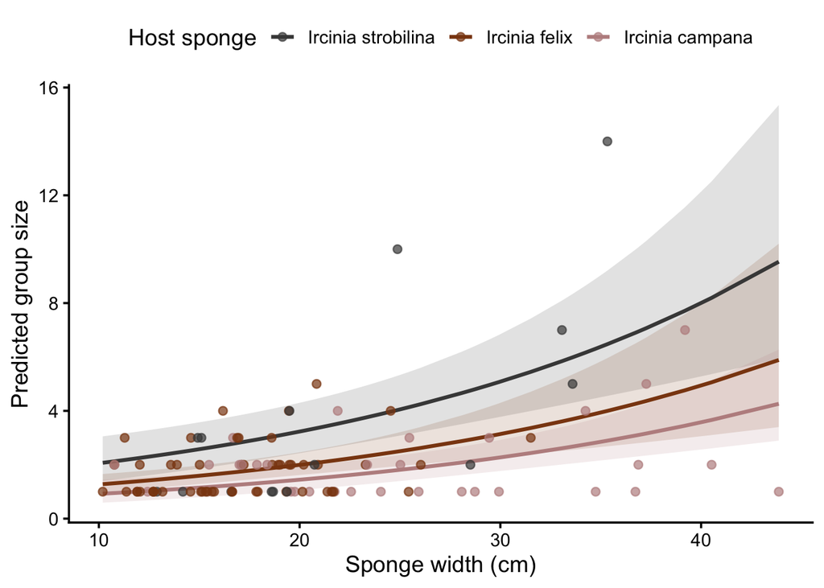

```r
ggplot() +
  geom_ribbon(
    data = pred_group,
    aes(x = x, ymin = conf.low, ymax = conf.high, fill = group),
    alpha = 0.15
  ) +
  geom_line(
    data = pred_group,
    aes(x = x, y = predicted, colour = group),
    linewidth = 1.1
  ) +
  geom_point(
    data = groups_main,
    aes(x = Sponge_width_cm, y = Group_size, colour = S_species),
    size = 2, alpha = 0.7
  ) +
  scale_color_manual(values = c(
    "Ircinia campana"    = "rosybrown",
    "Ircinia felix"      = "saddlebrown",
    "Ircinia strobilina" = "grey28"
  )) +
  scale_fill_manual(values = c(
    "Ircinia campana"    = "rosybrown",
    "Ircinia felix"      = "saddlebrown",
    "Ircinia strobilina" = "grey28"
  ), guide = "none") +
  labs(
    x = "Sponge width (cm)",
    y = "Predicted group size",
    colour = "Host sponge"
  ) +
  theme_classic(base_size = 14) +
  theme(legend.position = "top")
```

```r
ggsave(file.path(output_dir, "Figure_S9.pdf"), width = 7, height = 5, units = "in")
```

## 4. Life history

This section evaluates sex and rank patterns, reproductive status and egg number, and the relationship between otolith-derived age and body size.

### Sexual structure - Figure 4A and 4B

```r
#social data
d <- social.all %>%
  mutate(
    Reef      = factor(Reef),
    Sponge_id = factor(Sponge_id),
    Rank      = factor(Rank),
    # robust sex mapping (edit levels if needed)
    sex = case_when(
      str_to_lower(is_male) %in% c("male","m","1","true","t") ~ "male",
      str_to_lower(is_male) %in% c("female","f","0","false","fa") ~ "female",
      TRUE ~ NA_character_
    ) %>% factor(levels = c("female","male")),
    # convenience scalers
    z_width = scale(Sponge_width_cm)[,1],
    z_grp   = scale(Group_size)[,1],
    z_TL    = scale(TL_mm)[,1]
  )

d.alt<- d%>%
  filter(!is_male == "na") #208 individuals left

summary(d)
```

```
##     ind_id          Sponge_width_cm     Depth          Group_size
##  Length:223         Min.   :10.19   Min.   : 4.400   Min.   : 1.000
##  Class :character   1st Qu.:16.62   1st Qu.: 6.300   1st Qu.: 2.000
##  Mode  :character   Median :20.14   Median : 7.000   Median : 3.000
##                     Mean   :22.74   Mean   : 7.092   Mean   : 3.807
##                     3rd Qu.:29.09   3rd Qu.: 7.800   3rd Qu.: 4.000
##                     Max.   :43.87   Max.   :12.600   Max.   :14.000
##
##      TL_mm            Rank       mt_lineage      nc_lineage      Sponge_id
##  Min.   : 7.34   1      :104   Min.   :2.000   Min.   :1.000   GRU_16 : 14
##  1st Qu.:12.19   2      : 55   1st Qu.:2.000   1st Qu.:2.000   GOL_03 : 10
##  Median :14.24   3      : 25   Median :2.000   Median :2.000   GOL_12 :  7
##  Mean   :14.38   4      : 14   Mean   :2.031   Mean   :1.825   GRU_09 :  7
##  3rd Qu.:16.55   5      :  7   3rd Qu.:2.000   3rd Qu.:2.000   GOL_01 :  5
##  Max.   :23.22   6      :  4   Max.   :3.000   Max.   :3.000   GOL_11 :  5
##                  (Other): 14   NA's   :92      NA's   :183     (Other):175
##   S_species           S_colour          Reef       AVG.TL_mm
##  Length:223         Length:223         CUR:  4   Min.   : 7.61
##  Class :character   Class :character   GOL:113   1st Qu.:13.37
##  Mode  :character   Mode  :character   GRU: 75   Median :14.37
##                                        LON: 31   Mean   :14.38
##                                                  3rd Qu.:15.69
##                                                  Max.   :20.81
##
##    is_male            egg_count            eggs             age
##  Length:223         Min.   :  0.000   Min.   :0.0000   Min.   :29.00
##  Class :character   1st Qu.:  0.000   1st Qu.:0.0000   1st Qu.:38.50
##  Mode  :character   Median :  0.000   Median :0.0000   Median :49.00
##                     Mean   :  9.789   Mean   :0.1166   Mean   :48.97
##                     3rd Qu.:  0.000   3rd Qu.:0.0000   3rd Qu.:55.50
##                     Max.   :180.000   Max.   :1.0000   Max.   :80.00
##                                                        NA's   :192
##      Rank_n           sex          z_Sponge_width_cm.V1
##  Min.   : 1.000   female:162   Min.   :-1.50717791521e+00
##  1st Qu.: 1.000   male  : 45   1st Qu.:-7.35372860738e-01
##  Median : 2.000   NA's  : 16   Median :-3.12198324987e-01
##  Mean   : 2.404                Mean   : 3.00000000000e-16
##  3rd Qu.: 3.000                3rd Qu.: 7.62328656700e-01
##  Max.   :14.000                Max.   : 2.53785196132e+00
##
##           z_TL_mm.V1             z_width            z_grp
##  Min.   :-2.24272899710e+00   Min.   :-1.5072   Min.   :-0.81922
##  1st Qu.:-6.98387190758e-01   1st Qu.:-0.7354   1st Qu.:-0.52739
##  Median :-4.56241592124e-02   Median :-0.3122   Median :-0.23556
##  Mean   :-5.00000000000e-16   Mean   : 0.0000   Mean   : 0.00000
##  3rd Qu.: 6.88336225038e-01   3rd Qu.: 0.7623   3rd Qu.: 0.05627
##  Max.   : 2.81379633995e+00   Max.   : 2.5379   Max.   : 2.97457
##
##       z_TL
##  Min.   :-2.24273
##  1st Qu.:-0.69839
##  Median :-0.04562
##  Mean   : 0.00000
##  3rd Qu.: 0.68834
##  Max.   : 2.81380
##
```

```r
table(d$Rank, useNA="ifany")
```

```
##
##   1   2   3   4   5   6   7   8   9  10  11  12  13  14
## 104  55  25  14   7   4   4   2   2   2   1   1   1   1
```

```r
table(d$sex, useNA="ifany")
```

```
##
## female   male   <NA>
##    162     45     16
```

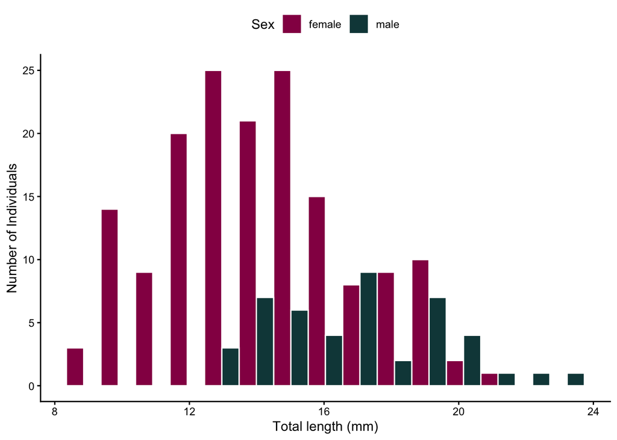

```r
sex_str<- ggplot(d.alt, aes(x = TL_mm, fill = sex)) +
  geom_histogram(position = "dodge", bins = 15, color = "white") +
  scale_fill_manual(values = c(female = "#950952", male = "#104547")) +
  labs(x = "Total length (mm)",
       y = "Number of Individuals",
       fill = "Sex") +
  theme_classic()+
  theme(legend.position = "top")

sex_str
```

```r
ggsave(file.path(output_dir, "Figure_4A.pdf"), plot = sex_str, width = 5, height = 4, units = "in")
```

How do social rank, sex, and habitat size together shape individual body size?

```r
#count individuals per rank x sex
sex_rank_df <- d.alt %>%
  mutate(
    Rank_n = as.numeric(as.character(Rank)),
    sex    = tolower(sex)
  ) %>%
  filter(Rank_n %in% 1:7, sex %in% c("male","female")) %>%
  count(Rank_n, sex, name = "n") %>%
  group_by(sex) %>%
  mutate(
    total_sex = sum(n),
    prop_sex  = n / total_sex
  ) %>%
  ungroup()

sex_rank_df
```

```
## # A tibble: 14 × 5
##    Rank_n sex        n total_sex prop_sex
##     <dbl> <chr>  <int>     <int>    <dbl>
##  1      1 female    74       154   0.481
##  2      1 male      26        43   0.605
##  3      2 female    40       154   0.260
##  4      2 male      10        43   0.233
##  5      3 female    21       154   0.136
##  6      3 male       2        43   0.0465
##  7      4 female    10       154   0.0649
##  8      4 male       2        43   0.0465
##  9      5 female     5       154   0.0325
## 10      5 male       1        43   0.0233
## 11      6 female     2       154   0.0130
## 12      6 male       1        43   0.0233
## 13      7 female     2       154   0.0130
## 14      7 male       1        43   0.0233
```

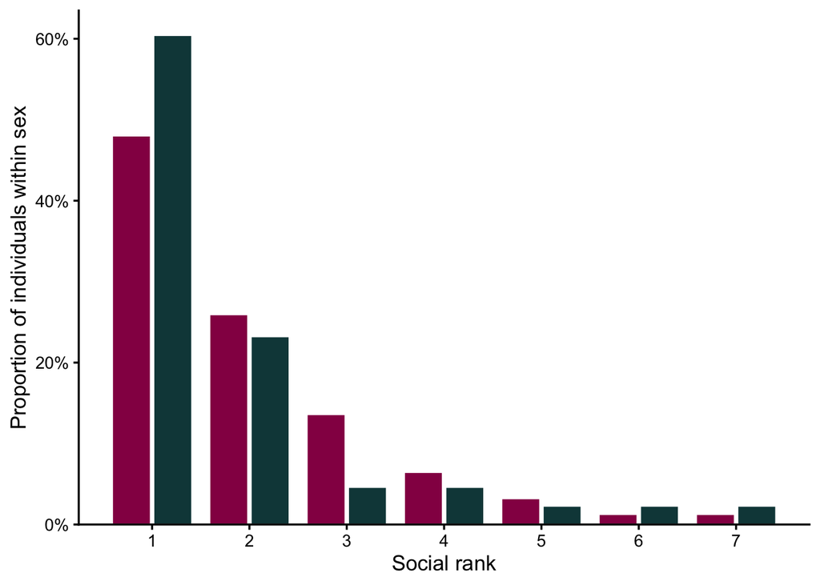

```r
#side-by-side bars per rank
sex_prop<-ggplot(sex_rank_df, aes(x = Rank_n, y = prop_sex, fill = sex)) +
  geom_col(position = position_dodge(width = 0.85), width = 0.8, color = "white") +
  scale_y_continuous(labels = percent_format(accuracy = 1),
                     limits = c(0, NA), expand = expansion(mult = c(0, 0.05))) +
  scale_x_continuous(breaks = 1:7) +
  scale_fill_manual(values = c("female" = "#950952", "male" = "#104547"),
                    name = "Sex") +
  labs(
    x = "Social rank",
    y = "Proportion of individuals within sex"
  ) +
  theme_classic(base_size = 13)+
  theme(legend.position = "none")

sex_prop
```

```r
ggsave(file.path(output_dir, "Figure_4B.pdf"), plot = sex_prop, width = 6, height = 4, units = "in")
```

### Sex, social rank, and body size

This linear mixed model tests whether males and females differ in body size at comparable ranks while controlling for sponge width and repeated observations within sponges (Supplementary Figure S10).

```r
d.alt <- d.alt %>%
  mutate(Rank_n = as.numeric(as.character(Rank)))

d.alt.f <- d.alt %>%
  filter(Rank_n <= 7)

m_add <- lmer(z_TL ~ Rank + sex + z_width + (1|Sponge_id), data = d.alt.f, REML = TRUE)
summary(m_add)
```

```
## Linear mixed model fit by REML. t-tests use Satterthwaite's method [
## lmerModLmerTest]
## Formula: z_TL ~ Rank + sex + z_width + (1 | Sponge_id)
##    Data: d.alt.f
##
## REML criterion at convergence: 426.8
##
## Scaled residuals:
##      Min       1Q   Median       3Q      Max
## -1.80680 -0.54232 -0.06904  0.46341  2.85589
##
## Random effects:
##  Groups    Name        Variance Std.Dev.
##  Sponge_id (Intercept) 0.5908   0.7687
##  Residual              0.1926   0.4389
## Number of obs: 197, groups:  Sponge_id, 100
##
## Fixed effects:
##              Estimate Std. Error        df t value Pr(>|t|)
## (Intercept)   0.36323    0.09602 117.53805   3.783 0.000246 ***
## Rank2        -0.66921    0.08625  92.29149  -7.759 1.12e-11 ***
## Rank3        -1.06637    0.12202  93.54410  -8.739 9.11e-14 ***
## Rank4        -1.36465    0.15786  89.45186  -8.645 1.97e-13 ***
## Rank5        -1.58236    0.21361  86.22420  -7.408 8.11e-11 ***
## Rank6        -1.53292    0.28827  83.71929  -5.318 8.59e-07 ***
## Rank7        -1.74096    0.28827  83.71929  -6.039 4.10e-08 ***
## sexmale       0.35985    0.10304 112.63011   3.492 0.000685 ***
## z_width       0.40599    0.09525  83.39347   4.262 5.30e-05 ***
## ---
## Signif. codes:  0 '***' 0.001 '**' 0.01 '*' 0.05 '.' 0.1 ' ' 1
##
## Correlation of Fixed Effects:
##         (Intr) Rank2  Rank3  Rank4  Rank5  Rank6  Rank7  sexmal
## Rank2   -0.289
## Rank3   -0.259  0.368
## Rank4   -0.205  0.285  0.339
## Rank5   -0.173  0.220  0.265  0.275
## Rank6   -0.119  0.158  0.189  0.198  0.214
## Rank7   -0.119  0.158  0.189  0.198  0.214  0.227
## sexmale -0.289  0.163  0.277  0.213  0.205  0.126  0.126
## z_width  0.269 -0.042 -0.067 -0.072 -0.083 -0.054 -0.054 -0.038
```

Interpreation:

```r
#SD of raw width (cm): this defines what "1 SD" means
sd_width <- sd(d.alt.f$Sponge_width_cm, na.rm = TRUE)

#Pull the standardized slope from the model directly
b_z <- fixef(m_add)[["z_width"]]

#Odds ratios
OR_1SD <- exp(b_z)                 # per 1 SD increase in width
OR_1cm <- exp(b_z / sd_width)      # equivalent OR per 1 cm increase

sd_width
```

```
## [1] 8.119009
```

```r
OR_1SD
```

```
## [1] 1.50079
```

```r
OR_1cm
```

```
## [1] 1.051276
```

```r
#Model-based predictions for every Rank × sex combo
emm_all <- emmeans(
  m_add,
  ~ Rank | sex,
  at = list(z_width = 0),
  type = "response"
) %>% as.data.frame()
```

```r
#Which combos were actually observed?
cells <- d.alt.f %>% count(Rank, sex, name = "n")

plot_df <- emm_all %>%
  left_join(cells, by = c("Rank","sex")) %>%
  mutate(
    obs = ifelse(is.na(n) | n == 0, "unobserved", "observed"),
    rank_num = as.numeric(as.character(Rank))
  )
```

[figure not shown]

```r
#plotting model predictions
pd <- position_dodge(width = 0.35)

sz_rank<- ggplot(plot_df, aes(x = rank_num, y = emmean, color = sex)) +
  geom_errorbar(aes(ymin = lower.CL, ymax = upper.CL),
                width = 0, position = pd, linewidth = 1) +
  geom_point(aes(shape = obs), position = pd, size = 4, stroke = 2, alpha = 0.7) +
  scale_shape_manual(values = c(observed = 16, unobserved = 1)) +  # solid vs hollow
  scale_color_manual(values = c(female = "#950952", male = "#104547")) +
  scale_x_continuous(breaks = sort(unique(plot_df$rank_num))) +
  labs(x = "Social Rank", y = "Predicted Total Length (mm)", color = "Sex") +
  theme_classic(base_size = 13)+
  theme(legend.position = "top")

sz_rank
```

```r
ggsave(file.path(output_dir, "Figure_S10.pdf"), plot = sz_rank, width = 5, height = 4, units = "in")
```

### Reproductive status and egg production

```r
#keeping only females
fem<- social.all %>%
  filter(is_male == 0)
fem$Rank<- as.factor(fem$Rank)
```

```r
#organizing dataset
fem<- fem %>%
  mutate(
    has_eggs = factor(eggs, levels = c(0,1),
                      labels = c("no_eggs", "eggs")))
fem_egg<- fem %>%
  filter(has_eggs == "eggs")

sum<- fem_egg%>%
  summarize(
    eggs_avg = mean(egg_count)) #obtaining counts for eggs

fem_per<- fem %>%
  count(has_eggs) %>%
  mutate(percent = 100 * n / sum(n))
```

#### Gravid females across social ranks

Female total length is plotted by social rank and colored by egg status. This descriptive plot reproduces Supplementary Figure S11 and shows that gravid females are not restricted to rank 1.

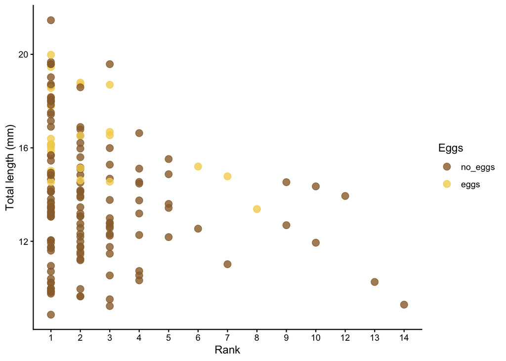

```r
egg_status<- ggplot(fem, aes(x = Rank, y = TL_mm, color = has_eggs)) +
  geom_point(size = 3, alpha = 0.8) +
  scale_color_manual(values = c("#9A6D38","#F4D35E")) +
  labs(x = "Rank",
       y = "Total length (mm)",
       color = "Eggs") +
  theme_classic()

egg_status
```

```r
ggsave(file.path(output_dir, "Figure_S11.pdf"), plot = egg_status, width = 5, height = 4, units = "in")
```

Are females carrying eggs significantly larger?

- Does female body size predict reproduction?
- Does habitat size (sponge size) further predict reproduction, beyond body size?

It lets you conclude whether habitat capacity influences whether females reproduce, not just how much they produce.

Bigger sponges could:

- allow more food / better flow → higher condition → more eggs, or
- simply allow more fish but not change per-female reproduction.

```r
#modeling the presence of eggs as a function of body size and sponge size
m_eggs_presence <- glmmTMB(
  has_eggs ~ scale(TL_mm) + scale(Sponge_width_cm) + (1 | Sponge_id),
  family = binomial,
  data = fem
)

summary(m_eggs_presence)
```

```
##  Family: binomial  ( logit )
## Formula:
## has_eggs ~ scale(TL_mm) + scale(Sponge_width_cm) + (1 | Sponge_id)
## Data: fem
##
##       AIC       BIC    logLik -2*log(L)  df.resid
##     126.0     138.3     -59.0     118.0       158
##
## Random effects:
##
## Conditional model:
##  Groups    Name        Variance Std.Dev.
##  Sponge_id (Intercept) 3.108    1.763
## Number of obs: 162, groups:  Sponge_id, 91
##
## Conditional model:
##                        Estimate Std. Error z value Pr(>|z|)
## (Intercept)            -2.95121    0.92379  -3.195  0.00140 **
## scale(TL_mm)            1.50822    0.54925   2.746  0.00603 **
## scale(Sponge_width_cm)  0.04344    0.38382   0.113  0.90989
## ---
## Signif. codes:  0 '***' 0.001 '**' 0.01 '*' 0.05 '.' 0.1 ' ' 1
```

```r
#sd(fem$TL_mm, na.rm = TRUE)
```

Only female body size has a direct effect on the presence of eggs.

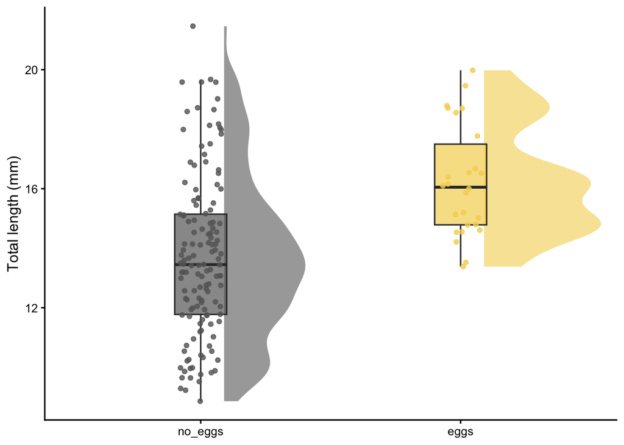

```r
#Visualizing eggs status - rainclound plot
ggplot(fem, aes(x = has_eggs, y = TL_mm, fill = has_eggs)) +
  stat_halfeye(
    adjust = .6,
    width = .5,
    .width = 0,
    justification = -.2,
    alpha = .6,
    color = NA
  ) +
  geom_boxplot(
    width = .2,
    outlier.shape = NA,
    alpha = .7
  ) +
  geom_jitter(
    aes(color = has_eggs),
    width = .08,
    size = 1.4,
    alpha = .8
  ) +

  scale_fill_manual(values = c("grey40","#F4D35E")) +
  scale_color_manual(values = c("grey40","#F4D35E")) +

  labs(y = "Total length (mm)") +
  theme_classic(base_size = 12) +
  theme(legend.position = "none", axis.title.x = element_blank())
```

```r
ggsave(file.path(output_dir, "Figure_4C.pdf"), width = 5, height = 4, units = "in")
```

Females carrying eggs were significantly larger and sponge size has no direct effect.

- But are the bigger females having more eggs (egg count)?

```r
#modeling egg count as a function of body size and sponge size
#count data - overdisperse - negative binomial
m_egg_count <- glmmTMB(
  egg_count ~ scale(TL_mm) + scale(Sponge_width_cm) + (1 | Sponge_id),
  family = nbinom2,
  data   = fem_egg)

summary(m_egg_count)
```

```
##  Family: nbinom2  ( log )
## Formula:
## egg_count ~ scale(TL_mm) + scale(Sponge_width_cm) + (1 | Sponge_id)
## Data: fem_egg
##
##       AIC       BIC    logLik -2*log(L)  df.resid
##     236.9     243.2    -113.4     226.9        21
##
## Random effects:
##
## Conditional model:
##  Groups    Name        Variance  Std.Dev.
##  Sponge_id (Intercept) 2.999e-10 1.732e-05
## Number of obs: 26, groups:  Sponge_id, 22
##
## Dispersion parameter for nbinom2 family (): 22.5
##
## Conditional model:
##                        Estimate Std. Error z value Pr(>|z|)
## (Intercept)             4.39744    0.04683   93.89  < 2e-16 ***
## scale(TL_mm)            0.20590    0.05038    4.09 4.37e-05 ***
## scale(Sponge_width_cm)  0.10174    0.05041    2.02   0.0436 *
## ---
## Signif. codes:  0 '***' 0.001 '**' 0.01 '*' 0.05 '.' 0.1 ' ' 1
```

```r
#sd(fem$TL_mm[fem$has_eggs == "eggs"], na.rm = TRUE)
```

```r
pred_egg <- ggpredict(m_egg_count, terms = "TL_mm [all]")
```

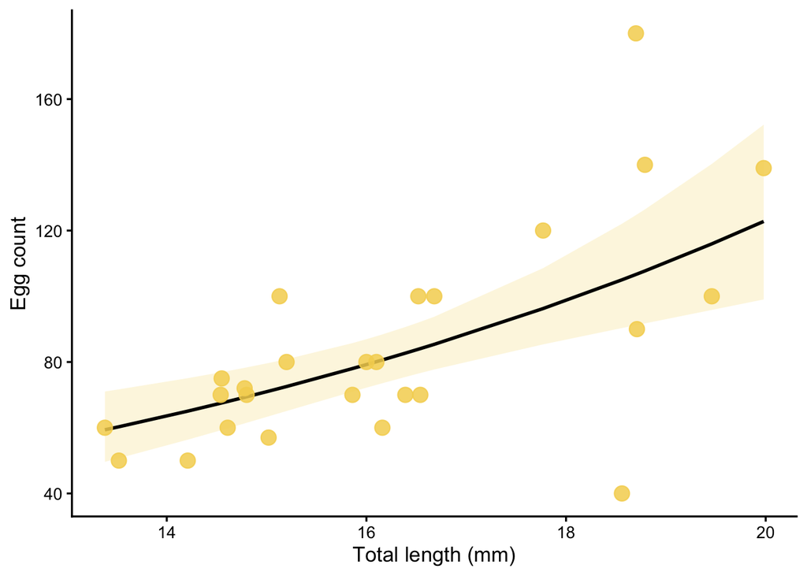

```r
egg_count<- ggplot() +
  geom_ribbon(
    data = pred_egg,
    aes(x = x, ymin = conf.low, ymax = conf.high),
    fill = "#F4D35E",
    alpha = 0.2
  ) +
  geom_line(
    data = pred_egg,
    aes(x = x, y = predicted),
    linewidth = 1
  ) +
  geom_point(
    data = fem_egg,
    aes(x = TL_mm, y = egg_count),
    colour = "#F4D35E",
    size = 4,
    alpha = 0.85
  ) +
  labs(
    x = "Total length (mm)",
    y = "Egg count"
  ) +
  theme_classic(base_size = 13)

egg_count
```

```r
ggsave(file.path(output_dir, "Figure_4D.pdf"), plot = egg_count, width = 5, height = 4, units = "in")
```

### Age structure and body size

The otolith-aged subset is used to summarize age distributions and test whether age, sex, dominant status, group size, and sponge width explain body size.

```r
oto<- social.all %>%
  filter(!is.na(age)) #31 individuals

summary(oto$age)
```

```
##    Min. 1st Qu.  Median    Mean 3rd Qu.    Max.
##   29.00   38.50   49.00   48.97   55.50   80.00
```

```r
head(oto)
```

```
##      ind_id Sponge_width_cm Depth Group_size TL_mm Rank mt_lineage nc_lineage
## 1 Risor_034        39.19804   6.3          7 14.68    3          2         NA
## 2 Risor_035        39.19804   6.3          7 19.67    1          2         NA
## 3 Risor_036        39.19804   6.3          7 16.79    2          2         NA
## 4 Risor_037        39.19804   6.3          7 13.19    4          2         NA
## 5 Risor_038        39.19804   6.3          7 12.18    5          2         NA
## 6 Risor_039        39.19804   6.3          7  8.99    6          2         NA
##   Sponge_id       S_species S_colour Reef AVG.TL_mm is_male egg_count eggs age
## 1    GOL_12 Ircinia campana   Medium  GOL     13.45       0         0    0  39
## 2    GOL_12 Ircinia campana   Medium  GOL     13.45       0         0    0  80
## 3    GOL_12 Ircinia campana   Medium  GOL     13.45       0         0    0  49
## 4    GOL_12 Ircinia campana   Medium  GOL     13.45       0         0    0  39
## 5    GOL_12 Ircinia campana   Medium  GOL     13.45       0         0    0  49
## 6    GOL_12 Ircinia campana   Medium  GOL     13.45      na         0    0  29
##   Rank_n    sex z_Sponge_width_cm     z_TL_mm
## 1      3 female          1.976785  0.09448108
## 2      1 female          1.976785  1.68340182
## 3      2 female          1.976785  0.76634937
## 4      4 female          1.976785 -0.37996620
## 5      5 female          1.976785 -0.70157140
## 6      6   <NA>          1.976785 -1.71733436
```

```r
#organizing otolith data
oto <- transform(oto,
  Age_c = scale(age, center = TRUE, scale = FALSE),
  Group_size_c = scale(Group_size, center = TRUE, scale = FALSE),
  Sponge_c = scale(Sponge_width_cm, center = TRUE, scale = FALSE)
)

oto<- oto %>%
  mutate(Rank_num = as.numeric(as.character(Rank)))

oto<- oto %>%
    mutate(
    Rank1 = ifelse(Rank_num == 1, "Rank1", "NotRank1"),
    Rank1 = factor(Rank1, levels = c("NotRank1", "Rank1")))

oto<- oto %>%
  mutate(
    sex = case_when(
      str_to_lower(is_male) %in% c("male","m","1","true","t") ~ "male",
      str_to_lower(is_male) %in% c("female","f","0","false","fa") ~ "female",
      TRUE ~ NA_character_
    ) %>% factor(levels = c("female","male")))
```

```r
#Obtaining basic metrics

age_summary <- oto %>%
  summarise(
    n_age      = n(),
    mean_age   = mean(age, na.rm = TRUE),
    sd_age     = sd(age, na.rm = TRUE),
    min_age    = min(age, na.rm = TRUE),
    max_age    = max(age, na.rm = TRUE),
    mean_TL    = mean(TL_mm, na.rm = TRUE),
    sd_TL      = sd(TL_mm, na.rm = TRUE),
    min_TL     = min(TL_mm, na.rm = TRUE),
    max_TL     = max(TL_mm, na.rm = TRUE)
  )
age_summary
```

```
##   n_age mean_age  sd_age min_age max_age  mean_TL    sd_TL min_TL max_TL
## 1    31 48.96774 14.0937      29      80 14.74839 3.271788   8.65  23.22
```

```r
age_by_sex <- oto %>%
  group_by(sex) %>%
  summarise(
    n          = n(),
    mean_age   = mean(age, na.rm = TRUE),
    sd_age     = sd(age, na.rm = TRUE),
    mean_TL    = mean(TL_mm, na.rm = TRUE),
    sd_TL      = sd(TL_mm, na.rm = TRUE),
    .groups = "drop"
  )
age_by_sex
```

```
## # A tibble: 3 × 6
##   sex        n mean_age sd_age mean_TL sd_TL
##   <fct>  <int>    <dbl>  <dbl>   <dbl> <dbl>
## 1 female    20     48.1  14.4    14.5  2.70
## 2 male       9     54.4  12.2    16.7  3.12
## 3 <NA>       2     33     5.66    8.82 0.240
```

```r
age_by_rank1 <- oto %>%
  group_by(Rank) %>%
  summarise(
    n          = n(),
    mean_age   = mean(age, na.rm = TRUE),
    sd_age     = sd(age, na.rm = TRUE),
    mean_TL    = mean(TL_mm, na.rm = TRUE),
    sd_TL      = sd(TL_mm, na.rm = TRUE),
    .groups = "drop"
  )
age_by_rank1
```

```
## # A tibble: 14 × 6
##     Rank     n mean_age sd_age mean_TL  sd_TL
##    <int> <int>    <dbl>  <dbl>   <dbl>  <dbl>
##  1     1     4     62.5  20.2    19.5   2.69
##  2     2     4     59.8   7.37   17.2   1.73
##  3     3     4     46.8  18.3    16.4   2.20
##  4     4     3     52.7  15.8    14.2   0.962
##  5     5     3     52.3   4.16   13.6   1.35
##  6     6     3     39.3  10.0    12.1   2.93
##  7     7     3     46     8.54   11.5   3.09
##  8     8     1     35    NA      14.7  NA
##  9     9     1     45    NA      14.5  NA
## 10    10     1     30    NA      14.4  NA
## 11    11     1     46    NA      14.0  NA
## 12    12     1     49    NA      13.9  NA
## 13    13     1     31    NA      10.3  NA
## 14    14     1     35    NA       9.29 NA
```

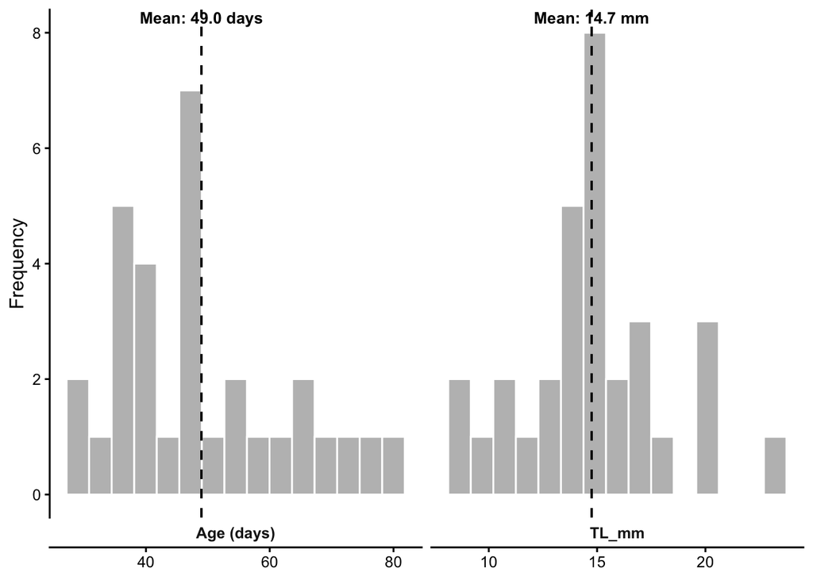

```r
#Obtaing age distribution and frequency
d_oto <- oto %>%
  dplyr::rename(Age_days = age)

#Pivot to long format
df_long <- d_oto %>%
  pivot_longer(
    cols = c(Age_days, TL_mm),
    names_to = "Measure",
    values_to = "Value"
  ) %>%
  mutate(
    Measure = recode(Measure,
                     Age_days = "Age (days)",
                     tL_mm = "Total length (mm)"),
    Units = if_else(Measure == "Age (days)", "days", "mm")
  )

#Calculate means for dashed line + label
means <- df_long %>%
  group_by(Measure, Units) %>%
  summarise(m = mean(Value, na.rm = TRUE), .groups = "drop") %>%
  mutate(lbl = sprintf("Mean: %.1f %s", m, Units))

#Visualizing age distribution
ggplot(df_long, aes(x = Value)) +
  geom_histogram(fill = "grey", color = "white", bins = 15) +
  facet_wrap(~Measure, scales = "free_x", nrow = 1, strip.position = "bottom") +
  geom_vline(data = means, aes(xintercept = m),
             linetype = "dashed", linewidth = 0.7) +
  geom_text(
    data = means,
    aes(x = m, y = Inf, label = lbl),
    vjust = 1.2, size = 3.5, fontface = "bold"
  ) +
  labs(x = NULL, y = "Frequency") +
  theme_classic(base_size = 12) +
  theme(
    #strip.placement = "outside",       # move strips outside plot panels
    #strip.position = "bottom",         # put them below the x-axis
    strip.text = element_text(face = "bold"),
    strip.background = element_blank()
  )
```

```r
ggsave(file.path(output_dir, "Figure_5A.pdf"), width = 5, height = 4, units = "in")
```

#### Do dominant individuals exhibit distinct age or size characteristics? (Figure 5B)

```r
# The corresponding mixed models had a zero Sponge_id random-effect variance
# (singular fits). Ordinary linear models therefore retain the supported
# fixed-effect hypotheses without interpreting an unsupported random effect.
fm0 <- lm(TL_mm ~ Age_c + Group_size + Sponge_c, data = oto)
fm1 <- lm(TL_mm ~ Age_c + sex + Rank1 + Group_size + Sponge_c, data = oto)
fm2 <- lm(TL_mm ~ Age_c * Rank1 + sex + Group_size + Sponge_c, data = oto)
fm3 <- lm(TL_mm ~ Age_c * sex + Rank1 + Group_size + Sponge_c, data = oto)
fm4 <- lm(TL_mm ~ Age_c * sex + Age_c * Rank1 + Group_size + Sponge_c, data = oto)
fm5 <- lm(TL_mm ~ Age_c * sex * Rank1 + Group_size + Sponge_c, data = oto)

aictab(list(fm0,fm1,fm2,fm3,fm4,fm5),
       modnames = c("Age","Age+sex+rank","Age*rank","Age*sex","Age*sex+Age*rank","3way"))
```

```
##
## Model selection based on AICc:
##
##                   K   AICc Delta_AICc AICcWt Cum.Wt     LL
## Age+sex+rank      7 129.21       0.00   0.75   0.75 -54.94
## Age*sex           8 132.70       3.49   0.13   0.88 -54.75
## Age*rank          8 133.07       3.86   0.11   0.98 -54.93
## Age*sex+Age*rank  9 136.91       7.70   0.02   1.00 -54.72
## Age               5 145.89      16.68   0.00   1.00 -66.75
## 3way             11 146.77      17.56   0.00   1.00 -54.62
```

```r
summary(fm1) #best-supported non-singular model
```

```
##
## Call:
## lm(formula = TL_mm ~ Age_c + sex + Rank1 + Group_size + Sponge_c,
##     data = oto)
##
## Residuals:
##     Min      1Q  Median      3Q     Max
## -3.6077 -0.7059 -0.1021  1.2092  3.2286
##
## Coefficients:
##             Estimate Std. Error t value Pr(>|t|)
## (Intercept) 15.51612    1.03297  15.021 2.22e-13 ***
## Age_c        0.09323    0.02890   3.226  0.00374 **
## sexmale      1.21948    0.81076   1.504  0.14616
## Rank1Rank1   3.03138    1.06236   2.853  0.00899 **
## Group_size  -0.12896    0.09847  -1.310  0.20327
## Sponge_c    -0.09619    0.14411  -0.667  0.51111
## ---
## Signif. codes:  0 '***' 0.001 '**' 0.01 '*' 0.05 '.' 0.1 ' ' 1
##
## Residual standard error: 1.806 on 23 degrees of freedom
##   (2 observations deleted due to missingness)
## Multiple R-squared:  0.6948, Adjusted R-squared:  0.6285
## F-statistic: 10.47 on 5 and 23 DF,  p-value: 2.466e-05
```

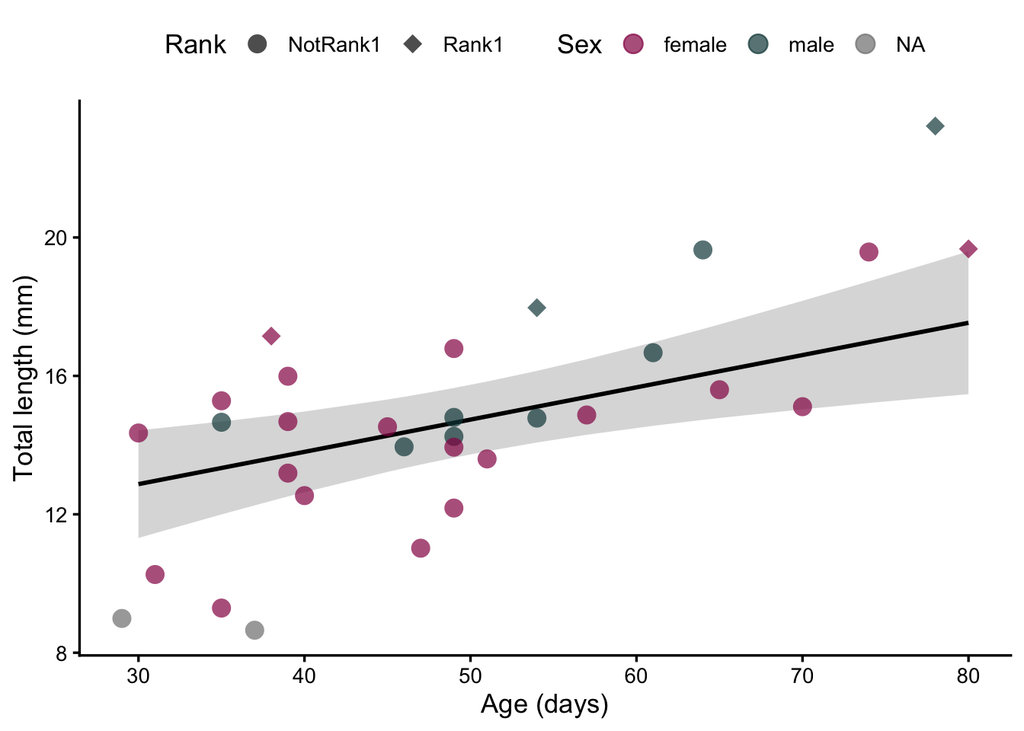

```r
#Organize predicted data for plotting
pred_age <- ggpredict(fm1, terms = "Age_c [all]")

age_mean <- mean(oto$age, na.rm = TRUE)
pred_age$age <- pred_age$x + age_mean

oto_age<- ggplot(oto, aes(x = age, y = TL_mm)) +
  geom_ribbon(
    data = pred_age,
    aes(x = age, ymin = conf.low, ymax = conf.high),
    inherit.aes = FALSE,
    alpha = 0.2
  ) +

  geom_line(
    data = pred_age,
    aes(x = age, y = predicted),
    inherit.aes = FALSE,
    linewidth = 1
  ) +

  geom_point(
    aes(color = sex, shape = Rank1),
    size = 4,
    alpha = 0.7
  ) +

  scale_color_manual(values = c(female = "#950952", male = "#104547")) +
  scale_shape_manual(values = c(NotRank1 = 16, Rank1 = 18)) +

  labs(
    x = "Age (days)",
    y = "Total length (mm)",
    color = "Sex",
    shape = "Rank"
  ) +
  theme_classic(base_size = 13) +
  theme(legend.position = "top")

oto_age
```

```r
ggsave(file.path(output_dir, "Figure_5B.pdf"), width = 5, height = 4, units = "in")
```

#### Does *Risor ruber* age vary across sampled sponges?

Age, sex, and dominant status are displayed for each of the four sponges represented in the otolith subset. The expected output is Supplementary Figure S12; unidentified sex is retained as `NA` in the figure.

```r
summ_sponge<-oto %>%
  group_by(Sponge_id) %>%
  summarise(
    n_total   = n(),
    n_female  = sum(sex == "female", na.rm = TRUE),
    n_male    = sum(sex == "male", na.rm = TRUE),
    age_min   = min(age, na.rm = TRUE),
    age_max   = max(age, na.rm = TRUE),
    age_mean  = mean(age, na.rm = TRUE),
    .groups   = "drop"
  )

#write.csv(summ_sponge, "mean_age_sponge_supp.csv")
```

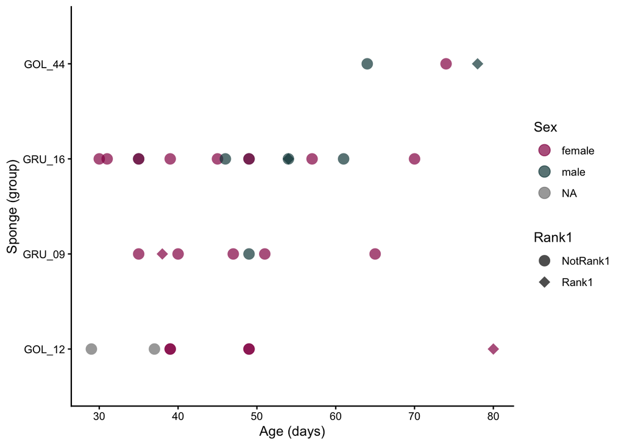

```r
oto2 <- oto %>%
  mutate(
    Sponge_id = fct_reorder(Sponge_id, age, .fun = mean, na.rm = TRUE))

#visualizing age variation across sampled sponges
ggplot(oto2, aes(x = age, y = Sponge_id)) +
   geom_point(aes( colour = sex, shape = Rank1),
    size = 4,
    alpha = 0.7
  ) +
    scale_color_manual(values = c(female = "#950952", male = "#104547")) +
  scale_shape_manual(values = c(NotRank1 = 16, Rank1 = 18)) +
  scale_size_continuous(name = "Total Length (mm)") +   # legend
  labs(x = "Age (days)", y = "Sponge (group)", colour = "Sex") +
  theme_classic()
```

```r
ggsave(file.path(output_dir, "Figure_S12.pdf"), width = 5, height = 4, units = "in")
```